# Supervised Learning - Foundations Project: ReCell

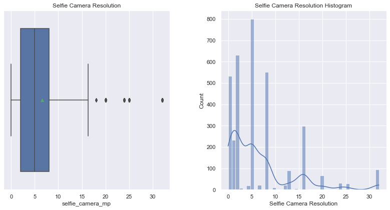

```python
plt.figure(figsize=(17, 6))

plt.subplot(131)
plt.title("Selfie Camera Resolution")
plt.xlabel("Selfie Camera Resolution")
sns.boxplot(data=df, x="selfie_camera_mp", showmeans=True)

plt.subplot(132)
plt.title("Selfie Camera Resolution Histogram")
plt.xlabel("Selfie Camera Resolution")
sns.histplot(data=df, x="selfie_camera_mp", kde=True)

plt.tight_layout(w_pad=5)
```

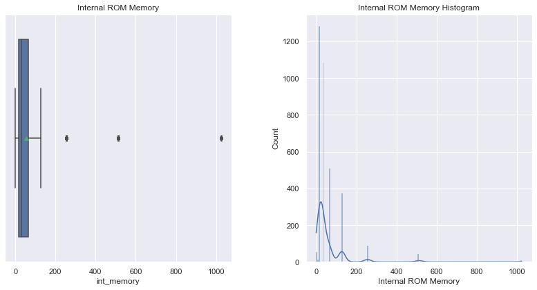

```python
plt.figure(figsize=(17, 6))

plt.subplot(131)
plt.title("Internal ROM Memory")
plt.xlabel("Internal ROM Memory")
sns.boxplot(data=df, x="int_memory", showmeans=True)

plt.subplot(132)
plt.title("Internal ROM Memory Histogram")
plt.xlabel("Internal ROM Memory")
sns.histplot(data=df, x="int_memory", kde=True)

plt.tight_layout(w_pad=5)
```

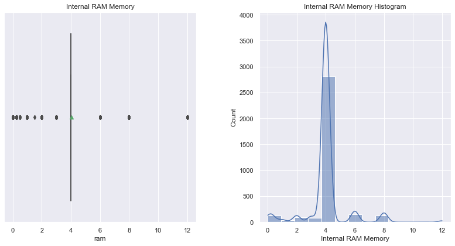

```python
plt.figure(figsize=(17, 6))

plt.subplot(131)
plt.title("Internal RAM Memory")
plt.xlabel("Internal RAM Memory")
sns.boxplot(data=df, x="ram", showmeans=True)

plt.subplot(132)
plt.title("Internal RAM Memory Histogram")
plt.xlabel("Internal RAM Memory")
sns.histplot(data=df, x="ram", kde=True)

plt.tight_layout(w_pad=5)
```

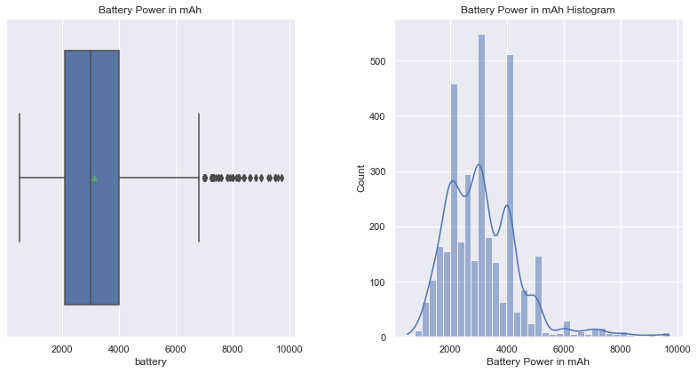

```python
plt.figure(figsize=(17, 6))

plt.subplot(131)
plt.title("Battery Power in mAh")
plt.xlabel("Battery Power in mAh")
sns.boxplot(data=df, x="battery", showmeans=True)

plt.subplot(132)
plt.title("Battery Power in mAh Histogram")
plt.xlabel("Battery Power in mAh")
sns.histplot(data=df, x="battery", kde=True)

plt.tight_layout(w_pad=5)
```

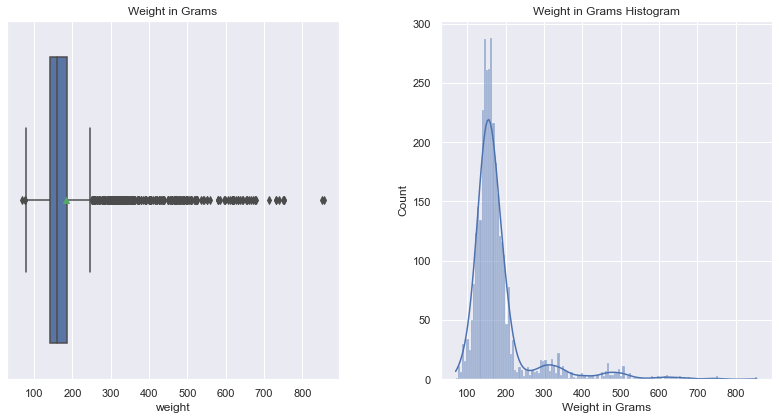

```python
plt.figure(figsize=(17, 6))

plt.subplot(131)
plt.title("Weight in Grams")
plt.xlabel("Weight in Grams")
sns.boxplot(data=df, x="weight", showmeans=True)

plt.subplot(132)
plt.title("Weight in Grams Histogram")
plt.xlabel("Weight in Grams")
sns.histplot(data=df, x="weight", kde=True)

plt.tight_layout(w_pad=5)
```

```python
print("Number of days used:")
print(df["days_used"].value_counts())
```

```
Number of days used:
578    13
601    13
564    13
682    12
683    12
       ..
245     1
253     1
269     1
307     1
149     1
Name: days_used, Length: 924, dtype: int64
```

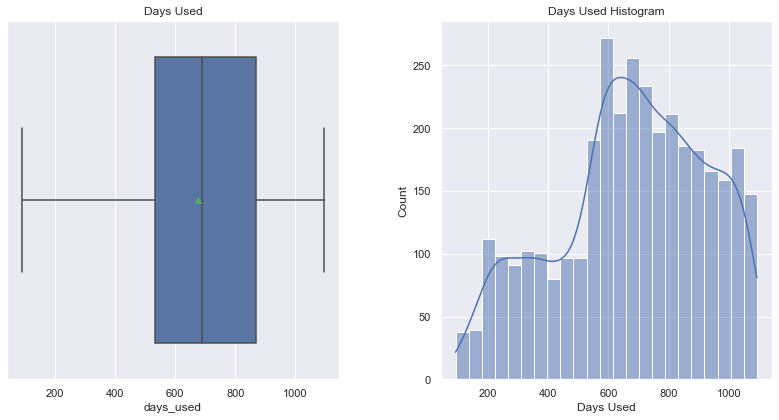

```python
plt.figure(figsize=(17, 6))

plt.subplot(131)
plt.title("Days Used")
plt.xlabel("Days Used")
sns.boxplot(data=df, x="days_used", showmeans=True)

plt.subplot(132)
plt.title("Days Used Histogram")
plt.xlabel("Days Used")
sns.histplot(data=df, x="days_used", kde=True)

plt.tight_layout(w_pad=5)
```

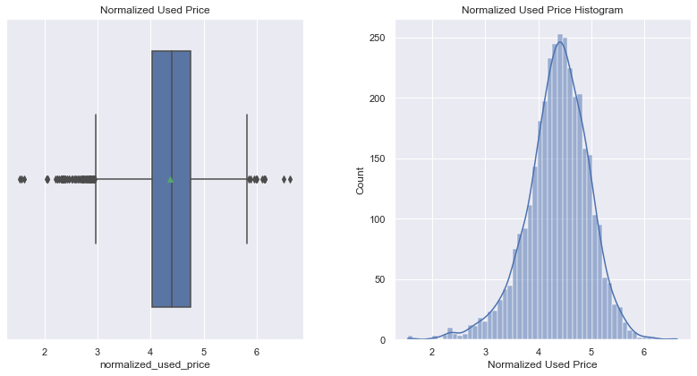

```python
plt.figure(figsize=(17, 6))

plt.subplot(131)
plt.title("Normalized Used Price")
plt.xlabel("Normalized Used Price")
sns.boxplot(data=df, x="normalized_used_price", showmeans=True)

plt.subplot(132)
plt.title("Normalized Used Price Histogram")
plt.xlabel("Normalized Used Price")
sns.histplot(data=df, x="normalized_used_price", kde=True)

plt.tight_layout(w_pad=5)
```

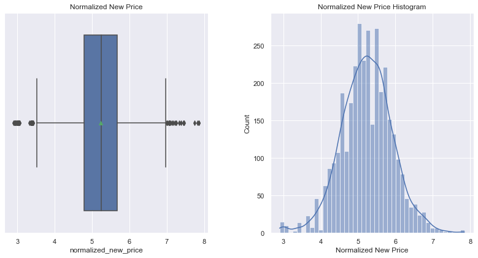

```python
plt.figure(figsize=(17, 6))

plt.subplot(131)
plt.title("Normalized New Price")
plt.xlabel("Normalized New Price")
sns.boxplot(data=df, x="normalized_new_price", showmeans=True)

plt.subplot(132)
plt.title("Normalized New Price Histogram")
plt.xlabel("Normalized New Price")
sns.histplot(data=df, x="normalized_new_price", kde=True)

plt.tight_layout(w_pad=5)
```

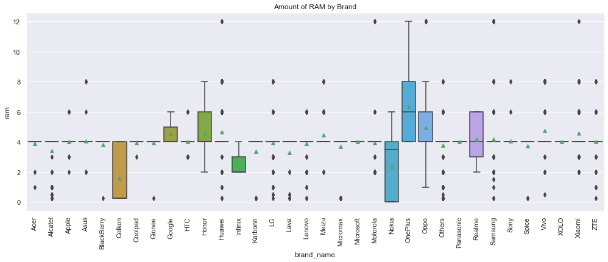

```python
plt.figure(figsize=(17, 6))
plt.title("Amount of RAM by Brand")
plt.xlabel("Amount of RAM by Brand")
plt.xticks(rotation=90)
sns.boxplot(data=df, x="brand_name", y="ram", showmeans=True)
```

```
There are 341 phones with batteries larger than 4500 mAh

Number of phones with large batteries by brand name:
Samsung       50
Others        41
Huawei        37
Xiaomi        31
Lenovo        28
Asus          22
Apple         17
Honor         14
Motorola      14
Vivo          13
LG            12
Realme        12
ZTE           10
Gionee        10
Acer           7
Sony           6
Infinix        6
Oppo           4
HTC            1
Alcatel        1
Micromax       1
Nokia          1
Panasonic      1
Google         1
Spice          1
BlackBerry     0
XOLO           0
Celkon         0
Lava           0
Coolpad        0
Karbonn        0
OnePlus        0
Microsoft      0
Meizu          0
Name: brand_name, dtype: int64
```

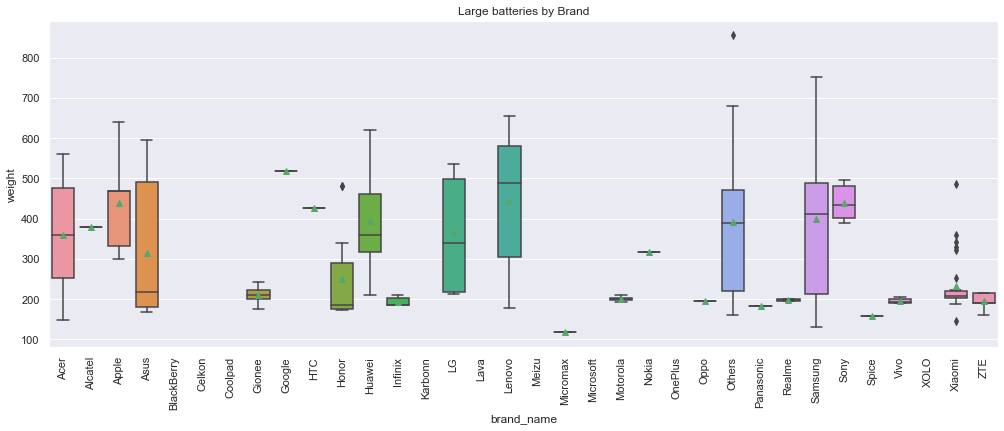

```python
tempdf = df[df.battery > 4500]

print("\nThere are", tempdf.shape[0], "phones with batteries larger than 4500 mAh\n")

print("Number of phones with large batteries by brand name:")
print(tempdf["brand_name"].value_counts())

plt.figure(figsize=(17, 6))
plt.title("Large batteries by Brand")
plt.xlabel("Large batteries by Brand")
plt.xticks(rotation=90)
sns.boxplot(data=tempdf, x="brand_name", y="weight", showmeans=True)

del tempdf  # free memory
```

```
There are 1099 phones with screen size larger than 6 inches

Number of phones with screen size larger than 6 inches by brand name:
Huawei        149
Samsung       119
Others         99
Vivo           80
Honor          72
Oppo           70
Lenovo         69
Xiaomi         69
LG             59
Motorola       42
Asus           41
Realme         40
Alcatel        26
Apple          24
Acer           19
Meizu          17
ZTE            17
OnePlus        16
Nokia          15
Sony           12
Infinix        10
Micromax        7
HTC             7
Google          4
XOLO            3
Gionee          3
Coolpad         3
Spice           2
Panasonic       2
Karbonn         2
Microsoft       1
Celkon          0
BlackBerry      0
Lava            0
Name: brand_name, dtype: int64
```

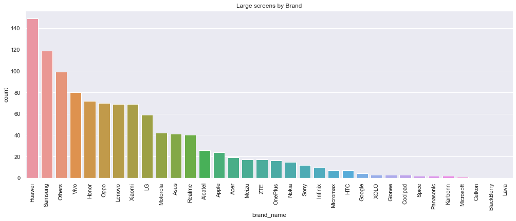

```python
tempdf = df[df.screen_size > 6 * 2.54]

print("\nThere are", tempdf.shape[0], "phones with screen size larger than 6 inches \n")

print("Number of phones with screen size larger than 6 inches by brand name:")
print(tempdf["brand_name"].value_counts())

plt.figure(figsize=(17, 6))
plt.title("Large screens by Brand")
plt.xlabel("Large screens by Brand")
plt.xticks(rotation=90)
sns.countplot(
    data=tempdf, x="brand_name", order=tempdf["brand_name"].value_counts().index
)

del tempdf  # free memory
```

```
There are 1721 phones with a selfie camera with a respolution greater than 8 megapixels

Number of phones with a selfie camera with a respolution greater than 8 megapixels:
Huawei        168
Others        158
Samsung       147
Xiaomi        122
Vivo          109
Honor         101
ZTE            90
Motorola       84
Oppo           75
HTC            68
Sony           67
LG             66
Asus           66
Lenovo         65
Meizu          60
Realme         41
Gionee         27
Alcatel        27
Panasonic      22
OnePlus        22
Micromax       21
Apple          20
Nokia          17
Coolpad        15
Google         14
Acer           11
BlackBerry      8
XOLO            8
Microsoft       8
Karbonn         7
Lava            6
Celkon          1
Infinix         0
Spice           0
Name: brand_name, dtype: int64
```

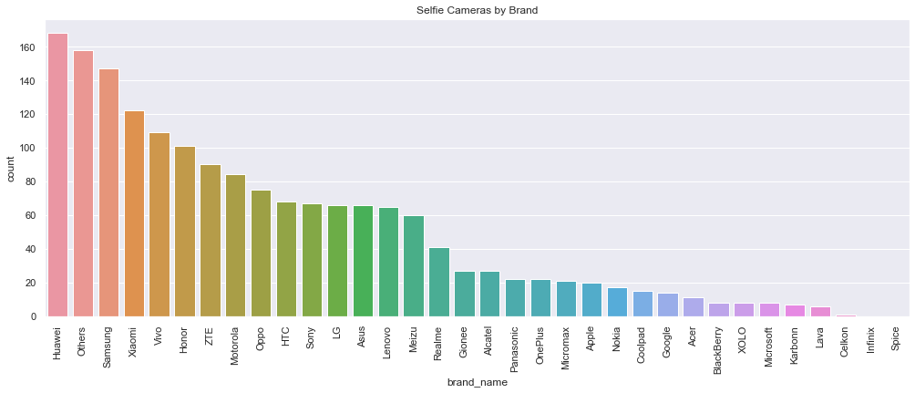

```python
tempdf = df[df.main_camera_mp > 8]

print(
    "\nThere are",
    tempdf.shape[0],
    "phones with a selfie camera with a respolution greater than 8 megapixels \n",
)

print(
    "Number of phones with a selfie camera with a respolution greater than 8 megapixels:"
)
print(tempdf["brand_name"].value_counts())

plt.figure(figsize=(17, 6))
plt.title("Selfie Cameras by Brand")
plt.xlabel("Selfie Cameras by Brand")
plt.xticks(rotation=90)
sns.countplot(
    data=tempdf, x="brand_name", order=tempdf["brand_name"].value_counts().index
)

del tempdf  # free memory
```

```
There are 94 phones with a main camera with a respolution greater than 16 megapixels

Number of phones with a main camera with a respolution greater than 16 megapixels:
Sony          37
Motorola      11
Others         9
HTC            6
Meizu          5
ZTE            5
Nokia          4
Microsoft      4
Asus           3
BlackBerry     2
Samsung        2
Lenovo         1
Xiaomi         1
Panasonic      1
Gionee         1
Acer           1
Honor          1
Alcatel        0
Google         0
XOLO           0
Vivo           0
Spice          0
Apple          0
Celkon         0
Realme         0
Lava           0
Huawei         0
Oppo           0
OnePlus        0
Infinix        0
Karbonn        0
LG             0
Micromax       0
Coolpad        0
Name: brand_name, dtype: int64
```

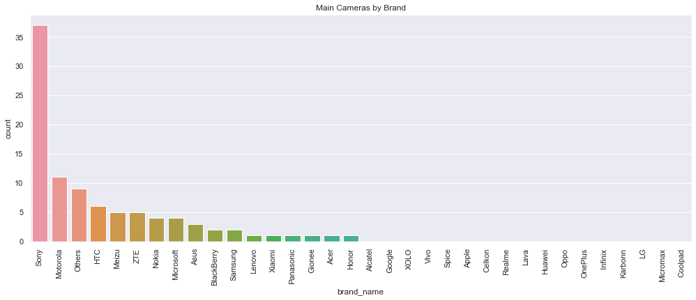

```python
tempdf = df[df.main_camera_mp > 16]

print(
    "\nThere are",
    tempdf.shape[0],
    "phones with a main camera with a respolution greater than 16 megapixels \n",
)

print(
    "Number of phones with a main camera with a respolution greater than 16 megapixels:"
)
print(tempdf["brand_name"].value_counts())

plt.figure(figsize=(17, 6))
plt.title("Main Cameras by Brand")
plt.xlabel("Main Cameras by Brand")
plt.xticks(rotation=90)
sns.countplot(
    data=tempdf, x="brand_name", order=tempdf["brand_name"].value_counts().index
)

del tempdf  # free memory
```

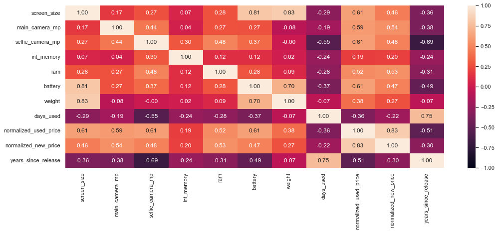

```python
columns = df.select_dtypes(include=np.number).columns.tolist()
# columns.remove("release_year")

plt.figure(figsize=(17, 6))
sns.heatmap(df[columns].corr(), annot=True, vmin=-1, vmax=1, fmt=".2f")
plt.show()
```

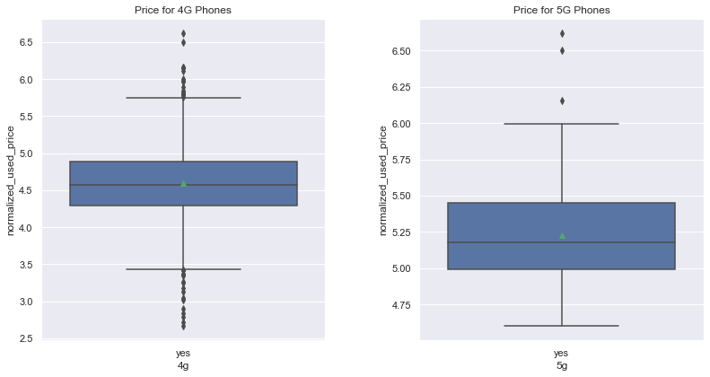

```python
fourdf = df[df["4g"] == "yes"]
fivedf = df[df["5g"] == "yes"]

plt.figure(figsize=(17, 6))

plt.subplot(131)
plt.title("Price for 4G Phones")
plt.xlabel("Price for 4G Phones")
sns.boxplot(
    data=fourdf, x="4g", y="normalized_used_price", showmeans=True,
)

plt.subplot(132)
plt.title("Price for 5G Phones")
plt.xlabel("Price for 5G Phones")
sns.boxplot(
    data=fivedf, x="5g", y="normalized_used_price", showmeans=True,
)

plt.tight_layout(w_pad=5)

del fourdf
del fivedf
```

### Observations:

There does not appear to be any great changes between the data before and after imputation.

## Data Preparation for Modeling

```python
# Making backup copy of dataframe

# df.to_csv("C:/Users/David/temp/used_device_data_transformed.csv", index=False)


# Read command if needed
df = pd.read_csv("C:/Users/David/temp/used_device_data_transformed.csv")
```

### Split the data

```python
# independent variables
ind = df.drop(["normalized_used_price"], axis=1)
# dependent variable
dep = df[["normalized_used_price"]]

print("Independent Variables")
print(ind.head())
print("\n\nDependent Variable")
dep.head()

# I think the code is easier to read using ind for indepenent and dep for dependent
```

```
Independent Variables
  brand_name       os  screen_size   4g   5g  main_camera_mp  \
0      Honor  Android        14.50  yes   no            13.0
1      Honor  Android        17.30  yes  yes            13.0
2      Honor  Android        16.69  yes  yes            13.0
3      Honor  Android        25.50  yes  yes            13.0
4      Honor  Android        15.32  yes   no            13.0

   selfie_camera_mp  int_memory  ram  battery  weight  days_used  \
0               5.0        64.0  3.0   3020.0   146.0        127
1              16.0       128.0  8.0   4300.0   213.0        325
2               8.0       128.0  8.0   4200.0   213.0        162
3               8.0        64.0  6.0   7250.0   480.0        345
4               8.0        64.0  3.0   5000.0   185.0        293

   normalized_new_price  years_since_release
0              4.715100                    1
1              5.519018                    1
2              5.884631                    1
3              5.630961                    1
4              4.947837                    1


Dependent Variable
```

|  | normalized_used_price |
| --- | --- |
| 0 | 4.307572 |
| 1 | 5.162097 |
| 2 | 5.111084 |
| 3 | 5.135387 |
| 4 | 4.389995 |

### Add intercept to independent variables

```python
ind = sm.add_constant(ind)
```

### Create Dummy Variables

```python
ind = pd.get_dummies(
    ind,
    columns=ind.select_dtypes(include=["object", "category"]).columns.tolist(),
    drop_first=True,
)

ind.head()
```

|  | const | screen_size | main_camera_mp | selfie_camera_mp | int_memory | ram | battery | weight | days_used | normalized_new_price | ... | brand_name_Spice | brand_name_Vivo | brand_name_XOLO | brand_name_Xiaomi | brand_name_ZTE | os_Others | os_Windows | os_iOS | 4g_yes | 5g_yes |
| --- | --- | --- | --- | --- | --- | --- | --- | --- | --- | --- | --- | --- | --- | --- | --- | --- | --- | --- | --- | --- | --- |
| 0 | 1.0 | 14.50 | 13.0 | 5.0 | 64.0 | 3.0 | 3020.0 | 146.0 | 127 | 4.715100 | ... | 0 | 0 | 0 | 0 | 0 | 0 | 0 | 0 | 1 | 0 |
| 1 | 1.0 | 17.30 | 13.0 | 16.0 | 128.0 | 8.0 | 4300.0 | 213.0 | 325 | 5.519018 | ... | 0 | 0 | 0 | 0 | 0 | 0 | 0 | 0 | 1 | 1 |
| 2 | 1.0 | 16.69 | 13.0 | 8.0 | 128.0 | 8.0 | 4200.0 | 213.0 | 162 | 5.884631 | ... | 0 | 0 | 0 | 0 | 0 | 0 | 0 | 0 | 1 | 1 |
| 3 | 1.0 | 25.50 | 13.0 | 8.0 | 64.0 | 6.0 | 7250.0 | 480.0 | 345 | 5.630961 | ... | 0 | 0 | 0 | 0 | 0 | 0 | 0 | 0 | 1 | 1 |
| 4 | 1.0 | 15.32 | 13.0 | 8.0 | 64.0 | 3.0 | 5000.0 | 185.0 | 293 | 4.947837 | ... | 0 | 0 | 0 | 0 | 0 | 0 | 0 | 0 | 1 | 0 |

5 rows × 49 columns

### Split the independent data 70:30 into train and test

```python
ind_train, ind_test, dep_train, dep_test = train_test_split(
    ind, dep, test_size=0.30, random_state=1
)
```

```python
print(
    "For training data, there are",
    ind_train.shape[0],
    "rows and",
    ind_train.shape[1],
    "columns.",
)
print(
    "For test data, there are",
    ind_test.shape[0],
    "rows and",
    ind_test.shape[1],
    "columns.",
)
```

```
For training data, there are 2417 rows and 49 columns.
For test data, there are 1037 rows and 49 columns.
```

## Model Building - Linear Regression

```python
%%time

olsmod = sm.OLS(dep_train, ind_train)
olsres = olsmod.fit()

# added the time call since I wanted to know how long this command took to execute
```

```
Wall time: 66 ms
```

```python
print(olsres.summary())
```

```
                              OLS Regression Results
=================================================================================
Dep. Variable:     normalized_used_price   R-squared:                       0.845
Model:                               OLS   Adj. R-squared:                  0.842
Method:                    Least Squares   F-statistic:                     268.7
Date:                   Sat, 21 May 2022   Prob (F-statistic):               0.00
Time:                           14:31:59   Log-Likelihood:                 123.85
No. Observations:                   2417   AIC:                            -149.7
Df Residuals:                       2368   BIC:                             134.0
Df Model:                             48
Covariance Type:               nonrobust
=========================================================================================
                            coef    std err          t      P>|t|      [0.025      0.975]
-----------------------------------------------------------------------------------------
const                     1.3156      0.071     18.454      0.000       1.176       1.455
screen_size               0.0244      0.003      7.163      0.000       0.018       0.031
main_camera_mp            0.0208      0.002     13.848      0.000       0.018       0.024
selfie_camera_mp          0.0135      0.001     11.997      0.000       0.011       0.016
int_memory                0.0001   6.97e-05      1.651      0.099   -2.16e-05       0.000
ram                       0.0230      0.005      4.451      0.000       0.013       0.033
battery               -1.689e-05   7.27e-06     -2.321      0.020   -3.12e-05   -2.62e-06
weight                    0.0010      0.000      7.480      0.000       0.001       0.001
days_used              4.216e-05   3.09e-05      1.366      0.172   -1.84e-05       0.000
normalized_new_price      0.4311      0.012     35.147      0.000       0.407       0.455
years_since_release      -0.0237      0.005     -5.193      0.000      -0.033      -0.015
brand_name_Alcatel        0.0154      0.048      0.323      0.747      -0.078       0.109
brand_name_Apple         -0.0038      0.147     -0.026      0.980      -0.292       0.285
brand_name_Asus           0.0151      0.048      0.314      0.753      -0.079       0.109
brand_name_BlackBerry    -0.0300      0.070     -0.427      0.669      -0.168       0.108
brand_name_Celkon        -0.0468      0.066     -0.707      0.480      -0.177       0.083
brand_name_Coolpad        0.0209      0.073      0.287      0.774      -0.122       0.164
brand_name_Gionee         0.0448      0.058      0.775      0.438      -0.068       0.158
brand_name_Google        -0.0326      0.085     -0.385      0.700      -0.199       0.133
brand_name_HTC           -0.0130      0.048     -0.270      0.787      -0.108       0.081
brand_name_Honor          0.0317      0.049      0.644      0.520      -0.065       0.128
brand_name_Huawei        -0.0020      0.044     -0.046      0.964      -0.089       0.085
brand_name_Infinix        0.1633      0.093      1.752      0.080      -0.019       0.346
brand_name_Karbonn        0.0943      0.067      1.405      0.160      -0.037       0.226
brand_name_LG            -0.0132      0.045     -0.291      0.771      -0.102       0.076
brand_name_Lava           0.0332      0.062      0.533      0.594      -0.089       0.155
```

[output cut: 19 more lines]

```
os_Windows               -0.0207      0.045     -0.459      0.646      -0.109       0.068
os_iOS                   -0.0663      0.146     -0.453      0.651      -0.354       0.221
4g_yes                    0.0528      0.016      3.326      0.001       0.022       0.084
5g_yes                   -0.0714      0.031     -2.268      0.023      -0.133      -0.010
==============================================================================
Omnibus:                      223.612   Durbin-Watson:                   1.910
Prob(Omnibus):                  0.000   Jarque-Bera (JB):              422.275
Skew:                          -0.620   Prob(JB):                     2.01e-92
Kurtosis:                       4.630   Cond. No.                     1.78e+05
==============================================================================

Notes:
[1] Standard Errors assume that the covariance matrix of the errors is correctly specified.
[2] The condition number is large, 1.78e+05. This might indicate that there are
strong multicollinearity or other numerical problems.
```

### Interpretation of R-squared

- The R-squared value tells us that our model can explain 84.5% of the variance in the training set.

## Model Performance Check

- We will be using metric functions defined in sklearn for RMSE, MAE, and $R^2$.
- We will define a function to calculate MAPE and adjusted $R^2$.

```python
pred = olsres.predict(ind_train)
r2 = r2_score(dep_train, pred)

adjr2 = olsres.rsquared_adj

rmse = np.sqrt(mean_squared_error(dep_train, pred))

mae = mean_absolute_error(dep_train, pred)

mape = np.mean(np.abs(dep_train - pred) / dep_train) * 100

print("For Training Data: \n"
"RMSE =", rmse,
"\nMAE =", mae,
"\nR-squared =", r2,
"\nAdj. R-squared =", adjr2,
"\nMAPE =", mape[0],
 )
```

```
For Training Data:
RMSE = 0.2298838019786819
MAE = 0.18032615182765027
R-squared = 0.8448860078512486
Adj. R-squared = 0.8417418053076928
MAPE = nan
```

R-squared is 84.48% and Adj. R-squared is 84.17% so the model is good.

```python
pred = olsres.predict(ind_test)
r2 = r2_score(dep_test, pred)

adjr2 = olsres.rsquared_adj

rmse = np.sqrt(mean_squared_error(dep_test, pred))

mae = mean_absolute_error(dep_test, pred)

mape = np.mean(np.abs(dep_test - pred) / dep_test) * 100

print(
    "For testing Data: \n" "RMSE =",
    rmse,
    "\nMAE =",
    mae,
    "\nR-squared =",
    r2,
    "\nAdj. R-squared =",
    adjr2,
    "\nMAPE =",
    mape[3],
)
```

```
For testing Data:
RMSE = 0.2383578942542656
MAE = 0.18474900805176403
R-squared = 0.842479123885892
Adj. R-squared = 0.8417418053076928
MAPE = nan
```

R-squared is 84.24% and Adj. R-squared is 84.17% so the model is good.  
Training and test numbers are very close to each other. This is good.

## Checking Linear Regression Assumptions

- In order to make statistical inferences from a linear regression model, it is important to ensure that the assumptions of linear regression are satisfied.

Will be checking the following Linear Regression assumptions:

1. **No Multicollinearity**
2. **Linearity of variables**
3. **Independence of error terms**
4. **Normality of error terms**
5. **No Heteroscedasticity**

### TEST FOR MULTICOLLINEARITY

- We will test for multicollinearity using VIF.
- **General Rule of thumb**:
  - If VIF is 1 then there is no correlation between the $k$th predictor and the remaining predictor variables.
  - If VIF exceeds 5 or is close to exceeding 5, we say there is moderate multicollinearity.
  - If VIF is 10 or exceeding 10, it shows signs of high multicollinearity.

```python
vif_series1 = pd.Series(
    [variance_inflation_factor(ind_train.values, i) for i in range(ind_train.shape[1])],
    index=ind_train.columns,
)
vif_series1 = vif_series1.sort_values(ascending=False)

print("VIF values: \n\n{}\n".format(vif_series1))

# code from file: LinearRegressionAssumptions_HandsOn.ipynb
# Added the sort to make the list easier to read
```

```
VIF values:

const                    227.744081
brand_name_Apple          13.057668
os_iOS                    11.784684
brand_name_Others          9.711034
screen_size                7.677290
brand_name_Samsung         7.539866
weight                     6.396749
brand_name_Huawei          5.983852
years_since_release        4.899007
brand_name_LG              4.849832
brand_name_Lenovo          4.558941
battery                    4.081780
brand_name_Oppo            3.971194
brand_name_ZTE             3.797581
brand_name_Xiaomi          3.719689
brand_name_Vivo            3.651437
brand_name_Nokia           3.479849
brand_name_HTC             3.410361
brand_name_Alcatel         3.405693
brand_name_Micromax        3.363521
brand_name_Honor           3.340687
brand_name_Asus            3.332038
brand_name_Motorola        3.274558
normalized_new_price       3.119430
brand_name_Sony            2.943161
selfie_camera_mp           2.812473
days_used                  2.660269
4g_yes                     2.467681
main_camera_mp             2.285051
ram                        2.282352
brand_name_Meizu           2.179607
brand_name_XOLO            2.138070
brand_name_Panasonic       2.105703
brand_name_Gionee          1.951272
brand_name_Realme          1.946812
brand_name_Microsoft       1.869751
os_Others                  1.859863
5g_yes                     1.813900
brand_name_Celkon          1.774721
brand_name_Lava            1.711360
brand_name_Spice           1.688863
brand_name_BlackBerry      1.632378
os_Windows                 1.596034
brand_name_Karbonn         1.573702
brand_name_Coolpad         1.468006
brand_name_OnePlus         1.437034
int_memory                 1.364152
brand_name_Google          1.321778
brand_name_Infinix         1.283955
dtype: float64
```

#### Remove/drop multicollinear columns one by one and observe the effect on our predictive model.

```python
ind_train2 = ind_train.drop(["brand_name_Apple"], axis=1)
olsmod_2 = sm.OLS(dep_train, ind_train2)
olsres_2 = olsmod_2.fit()
print("Baseline Adjusted R-squared:", np.round(olsres.rsquared_adj, 5))
print(
    "R-squared:",
    np.round(olsres_2.rsquared, 5),
    "\nAdjusted R-squared:",
    np.round(olsres_2.rsquared_adj, 5),
    "\nOn dropping brand_name_Apple adj. R-squared decreased by:",
    end="",
)
x = np.round(olsres.rsquared_adj - olsres_2.rsquared_adj, 5)
print(f"{x:.6f}")


del ind_train2, olsmod_2, olsres_2, x  # Free memory
```

```
Baseline Adjusted R-squared: 0.84174
R-squared: 0.84489
Adjusted R-squared: 0.84181
On dropping brand_name_Apple adj. R-squared decreased by:-0.000070
```

```python
ind_train2 = ind_train.drop(["os_iOS"], axis=1)
olsmod_2 = sm.OLS(dep_train, ind_train2)
olsres_2 = olsmod_2.fit()
print("Baseline Adjusted R-squared:", np.round(olsres.rsquared_adj, 5))
print(
    "R-squared:",
    np.round(olsres_2.rsquared, 5),
    "\nAdjusted R-squared:",
    np.round(olsres_2.rsquared_adj, 5),
    "\nOn dropping os_iOS adj. R-squared decreased by:",
    end="",
)
x = np.round(olsres.rsquared_adj - olsres_2.rsquared_adj, 5)
print(f"{x:.6f}")

del ind_train2, olsmod_2, olsres_2
```

```
Baseline Adjusted R-squared: 0.84174
R-squared: 0.84487
Adjusted R-squared: 0.84179
On dropping os_iOS adj. R-squared decreased by:-0.000050
```

```python
ind_train2 = ind_train.drop(["brand_name_Others"], axis=1)
olsmod_2 = sm.OLS(dep_train, ind_train2)
olsres_2 = olsmod_2.fit()
print("Baseline Adjusted R-squared:", np.round(olsres.rsquared_adj, 5))
print(
    "R-squared:",
    np.round(olsres_2.rsquared, 5),
    "\nAdjusted R-squared:",
    np.round(olsres_2.rsquared_adj, 5),
    "\nOn dropping brand_name_Others  adj. R-squared decreased by:",
    end="",
)
x = np.round(olsres.rsquared_adj - olsres_2.rsquared_adj, 5)
print(f"{x:.6f}")

del ind_train2, olsmod_2, olsres_2
```

```
Baseline Adjusted R-squared: 0.84174
R-squared: 0.84488
Adjusted R-squared: 0.84181
On dropping brand_name_Others  adj. R-squared decreased by:-0.000060
```

```python
ind_train2 = ind_train.drop(["screen_size"], axis=1)
olsmod_2 = sm.OLS(dep_train, ind_train2)
olsres_2 = olsmod_2.fit()
print("Baseline Adjusted R-squared:", np.round(olsres.rsquared_adj, 5))
print(
    "R-squared:",
    np.round(olsres_2.rsquared, 5),
    "\nAdjusted R-squared:",
    np.round(olsres_2.rsquared_adj, 5),
    "\nOn dropping screen_size adj. R-squared decreased by:",
    end="",
)
x = np.round(olsres.rsquared_adj - olsres_2.rsquared_adj, 5)
print(f"{x:.6f}")

del ind_train2, olsmod_2, olsres_2
```

```
Baseline Adjusted R-squared: 0.84174
R-squared: 0.84153
Adjusted R-squared: 0.83838
On dropping screen_size adj. R-squared decreased by:0.003360
```

```python
ind_train2 = ind_train.drop(["brand_name_Samsung"], axis=1)
olsmod_2 = sm.OLS(dep_train, ind_train2)
olsres_2 = olsmod_2.fit()
print("Baseline Adjusted R-squared:", np.round(olsres.rsquared_adj, 5))
print(
    "R-squared:",
    np.round(olsres_2.rsquared, 5),
    "\nAdjusted R-squared:",
    np.round(olsres_2.rsquared_adj, 5),
    "\nOn dropping brand_name_Samsung adj. R-squared decreased by:",
    end="",
)
x = np.round(olsres.rsquared_adj - olsres_2.rsquared_adj, 5)
print(f"{x:.6f}")

del ind_train2, olsmod_2, olsres_2
```

```
Baseline Adjusted R-squared: 0.84174
R-squared: 0.84485
Adjusted R-squared: 0.84177
On dropping brand_name_Samsung adj. R-squared decreased by:-0.000030
```

```python
ind_train2 = ind_train.drop(["weight"], axis=1)
olsmod_2 = sm.OLS(dep_train, ind_train2)
olsres_2 = olsmod_2.fit()
print("Baseline Adjusted R-squared:", np.round(olsres.rsquared_adj, 5))
print(
    "R-squared:",
    np.round(olsres_2.rsquared, 5),
    "\nAdjusted R-squared:",
    np.round(olsres_2.rsquared_adj, 5),
    "\nOn dropping weight adj. R-squared decreased by:",
    end="",
)
x = np.round(olsres.rsquared_adj - olsres_2.rsquared_adj, 5)
print(f"{x:.6f}")

del ind_train2, olsmod_2, olsres_2
```

```
Baseline Adjusted R-squared: 0.84174
R-squared: 0.84122
Adjusted R-squared: 0.83807
On dropping weight adj. R-squared decreased by:0.003670
```

```python
ind_train2 = ind_train.drop(["brand_name_Huawei"], axis=1)
olsmod_2 = sm.OLS(dep_train, ind_train2)
olsres_2 = olsmod_2.fit()
print("Baseline Adjusted R-squared:", np.round(olsres.rsquared_adj, 5))
print(
    "R-squared:",
    np.round(olsres_2.rsquared, 5),
    "\nAdjusted R-squared:",
    np.round(olsres_2.rsquared_adj, 5),
    "\nOn dropping brand_name_Huawei adj. R-squared decreased by:",
    end="",
)
x = np.round(olsres.rsquared_adj - olsres_2.rsquared_adj, 5)
print(f"{x:.6f}")

del ind_train2, olsmod_2, olsres_2
```

```
Baseline Adjusted R-squared: 0.84174
R-squared: 0.84489
Adjusted R-squared: 0.84181
On dropping brand_name_Huawei adj. R-squared decreased by:-0.000070
```

#### Analysis of Adjusted R-squared decreses

On dropping brand_name_Apple adj. R-squared decresed by: -0.000070  
On dropping os_iOS adj. R-squared decresed by: -0.000050  
On dropping brand_name_Others adj. R-squared decresed by: -0.000060  
On dropping screen_size adj. R-squared decresed by: 0.003360  
On dropping brand_name_Samsung adj. R-squared decresed by: -0.000030  
On dropping weight adj. R-squared decresed by: 0.003670  
On dropping brand_name_Huawei adj. R-squared decresed by: -0.000070

Following the Linear Regression Asssumptions Lecture, the columns with the largest change to R-squared should be dropped last. Therefore columns screen_size and weight are dropped last.

We are going to drop these columns in the following order based on the change to the R-squared value:

1. brand_name_Apple -0.00007
2. brand_name_Huawei -0.00007
3. brand_name_Others -0.00006
4. os_iOS -0.00005
5. brand_name_Samsung -0.00003
6. screen_size 0.00336
7. weight 0.00367

```python
ind_train = ind_train.drop(["brand_name_Apple"], axis=1)
```

```python
olsmod_mk2 = sm.OLS(dep_train, ind_train)
olsres_mk2 = olsmod_mk2.fit()
print(olsres_mk2.summary())
```

```
                              OLS Regression Results
=================================================================================
Dep. Variable:     normalized_used_price   R-squared:                       0.845
Model:                               OLS   Adj. R-squared:                  0.842
Method:                    Least Squares   F-statistic:                     274.5
Date:                   Sat, 21 May 2022   Prob (F-statistic):               0.00
Time:                           14:33:01   Log-Likelihood:                 123.85
No. Observations:                   2417   AIC:                            -151.7
Df Residuals:                       2369   BIC:                             126.2
Df Model:                             47
Covariance Type:               nonrobust
=========================================================================================
                            coef    std err          t      P>|t|      [0.025      0.975]
-----------------------------------------------------------------------------------------
const                     1.3155      0.071     18.475      0.000       1.176       1.455
screen_size               0.0244      0.003      7.178      0.000       0.018       0.031
main_camera_mp            0.0208      0.002     13.852      0.000       0.018       0.024
selfie_camera_mp          0.0135      0.001     12.048      0.000       0.011       0.016
int_memory                0.0001   6.97e-05      1.651      0.099   -2.16e-05       0.000
ram                       0.0229      0.005      4.459      0.000       0.013       0.033
battery               -1.689e-05   7.27e-06     -2.323      0.020   -3.11e-05   -2.63e-06
weight                    0.0010      0.000      7.484      0.000       0.001       0.001
days_used              4.217e-05   3.09e-05      1.367      0.172   -1.83e-05       0.000
normalized_new_price      0.4311      0.012     35.249      0.000       0.407       0.455
years_since_release      -0.0237      0.005     -5.198      0.000      -0.033      -0.015
brand_name_Alcatel        0.0156      0.046      0.338      0.736      -0.075       0.107
brand_name_Asus           0.0154      0.047      0.330      0.741      -0.076       0.107
brand_name_BlackBerry    -0.0296      0.069     -0.432      0.666      -0.164       0.105
brand_name_Celkon        -0.0466      0.065     -0.711      0.477      -0.175       0.082
brand_name_Coolpad        0.0212      0.072      0.294      0.769      -0.120       0.163
brand_name_Gionee         0.0450      0.057      0.793      0.428      -0.066       0.156
brand_name_Google        -0.0323      0.084     -0.386      0.700      -0.196       0.132
brand_name_HTC           -0.0128      0.047     -0.272      0.786      -0.105       0.079
brand_name_Honor          0.0319      0.048      0.668      0.504      -0.062       0.126
brand_name_Huawei        -0.0017      0.043     -0.040      0.968      -0.086       0.082
brand_name_Infinix        0.1636      0.093      1.768      0.077      -0.018       0.345
brand_name_Karbonn        0.0945      0.066      1.422      0.155      -0.036       0.225
brand_name_LG            -0.0129      0.044     -0.293      0.769      -0.099       0.073
brand_name_Lava           0.0334      0.062      0.543      0.587      -0.087       0.154
brand_name_Lenovo         0.0457      0.044      1.041      0.298      -0.040       0.132
```

[output cut: 18 more lines]

```
os_Windows               -0.0208      0.045     -0.460      0.645      -0.109       0.068
os_iOS                   -0.0698      0.059     -1.184      0.237      -0.185       0.046
4g_yes                    0.0527      0.016      3.327      0.001       0.022       0.084
5g_yes                   -0.0714      0.031     -2.272      0.023      -0.133      -0.010
==============================================================================
Omnibus:                      223.604   Durbin-Watson:                   1.910
Prob(Omnibus):                  0.000   Jarque-Bera (JB):              422.314
Skew:                          -0.620   Prob(JB):                     1.98e-92
Kurtosis:                       4.630   Cond. No.                     1.70e+05
==============================================================================

Notes:
[1] Standard Errors assume that the covariance matrix of the errors is correctly specified.
[2] The condition number is large, 1.7e+05. This might indicate that there are
strong multicollinearity or other numerical problems.
```

```python
vif_series1 = pd.Series(
    [variance_inflation_factor(ind_train.values, i) for i in range(ind_train.shape[1])],
    index=ind_train.columns,
)
vif_series1 = vif_series1.sort_values(ascending=False)

print("VIF values: \n\n{}\n".format(vif_series1))

# code from file: LinearRegressionAssumptions_HandsOn.ipynb
# Added the sort to make the list easier to read
```

```
VIF values:

const                    227.303871
brand_name_Others          9.075554
screen_size                7.643583
brand_name_Samsung         6.991538
weight                     6.394014
brand_name_Huawei          5.581714
years_since_release        4.890322
brand_name_LG              4.565534
brand_name_Lenovo          4.291839
battery                    4.079720
brand_name_Oppo            3.762937
brand_name_ZTE             3.604439
brand_name_Xiaomi          3.513125
brand_name_Vivo            3.447853
brand_name_Nokia           3.266268
brand_name_HTC             3.240658
brand_name_Alcatel         3.230773
brand_name_Micromax        3.214171
brand_name_Honor           3.160024
brand_name_Asus            3.145077
brand_name_Motorola        3.109867
normalized_new_price       3.102417
brand_name_Sony            2.799174
selfie_camera_mp           2.791121
days_used                  2.659799
4g_yes                     2.466689
main_camera_mp             2.284429
ram                        2.273686
brand_name_Meizu           2.092837
brand_name_XOLO            2.069729
brand_name_Panasonic       2.030895
os_iOS                     1.908608
brand_name_Gionee          1.886381
brand_name_Realme          1.878915
brand_name_Microsoft       1.835669
5g_yes                     1.805259
os_Others                  1.739572
brand_name_Celkon          1.731854
brand_name_Lava            1.670810
brand_name_Spice           1.655389
os_Windows                 1.593814
brand_name_BlackBerry      1.561121
brand_name_Karbonn         1.544264
brand_name_Coolpad         1.436852
brand_name_OnePlus         1.402445
int_memory                 1.364138
brand_name_Google          1.293163
brand_name_Infinix         1.265587
dtype: float64
```

```python
ind_train = ind_train.drop(["brand_name_Huawei"], axis=1)
```

```python
olsmod_mk3 = sm.OLS(dep_train, ind_train)
olsres_mk3 = olsmod_mk3.fit()
print(olsres_mk3.summary())
```

```
                              OLS Regression Results
=================================================================================
Dep. Variable:     normalized_used_price   R-squared:                       0.845
Model:                               OLS   Adj. R-squared:                  0.842
Method:                    Least Squares   F-statistic:                     280.6
Date:                   Sat, 21 May 2022   Prob (F-statistic):               0.00
Time:                           14:33:29   Log-Likelihood:                 123.85
No. Observations:                   2417   AIC:                            -153.7
Df Residuals:                       2370   BIC:                             118.4
Df Model:                             46
Covariance Type:               nonrobust
=========================================================================================
                            coef    std err          t      P>|t|      [0.025      0.975]
-----------------------------------------------------------------------------------------
const                     1.3141      0.061     21.469      0.000       1.194       1.434
screen_size               0.0244      0.003      7.187      0.000       0.018       0.031
main_camera_mp            0.0208      0.002     13.855      0.000       0.018       0.024
selfie_camera_mp          0.0135      0.001     12.070      0.000       0.011       0.016
int_memory                0.0001   6.97e-05      1.651      0.099   -2.16e-05       0.000
ram                       0.0229      0.005      4.462      0.000       0.013       0.033
battery               -1.689e-05   7.27e-06     -2.324      0.020   -3.11e-05   -2.64e-06
weight                    0.0010      0.000      7.486      0.000       0.001       0.001
days_used              4.219e-05   3.08e-05      1.368      0.171   -1.83e-05       0.000
normalized_new_price      0.4311      0.012     35.259      0.000       0.407       0.455
years_since_release      -0.0237      0.005     -5.199      0.000      -0.033      -0.015
brand_name_Alcatel        0.0170      0.031      0.552      0.581      -0.043       0.078
brand_name_Asus           0.0168      0.031      0.547      0.585      -0.043       0.077
brand_name_BlackBerry    -0.0282      0.059     -0.477      0.633      -0.144       0.088
brand_name_Celkon        -0.0452      0.056     -0.810      0.418      -0.155       0.064
brand_name_Coolpad        0.0226      0.063      0.362      0.717      -0.100       0.145
brand_name_Gionee         0.0464      0.045      1.040      0.299      -0.041       0.134
brand_name_Google        -0.0309      0.076     -0.407      0.684      -0.179       0.118
brand_name_HTC           -0.0113      0.031     -0.367      0.714      -0.072       0.049
brand_name_Honor          0.0334      0.031      1.067      0.286      -0.028       0.095
brand_name_Infinix        0.1651      0.085      1.940      0.052      -0.002       0.332
brand_name_Karbonn        0.0959      0.057      1.682      0.093      -0.016       0.208
brand_name_LG            -0.0115      0.026     -0.439      0.661      -0.063       0.040
brand_name_Lava           0.0348      0.051      0.684      0.494      -0.065       0.135
brand_name_Lenovo         0.0471      0.026      1.779      0.075      -0.005       0.099
brand_name_Meizu         -0.0111      0.041     -0.269      0.788      -0.092       0.070
```

[output cut: 17 more lines]

```
os_Windows               -0.0208      0.045     -0.461      0.645      -0.109       0.068
os_iOS                   -0.0683      0.047     -1.448      0.148      -0.161       0.024
4g_yes                    0.0527      0.016      3.337      0.001       0.022       0.084
5g_yes                   -0.0714      0.031     -2.275      0.023      -0.133      -0.010
==============================================================================
Omnibus:                      223.585   Durbin-Watson:                   1.910
Prob(Omnibus):                  0.000   Jarque-Bera (JB):              422.227
Skew:                          -0.620   Prob(JB):                     2.06e-92
Kurtosis:                       4.630   Cond. No.                     7.90e+04
==============================================================================

Notes:
[1] Standard Errors assume that the covariance matrix of the errors is correctly specified.
[2] The condition number is large, 7.9e+04. This might indicate that there are
strong multicollinearity or other numerical problems.
```

```python
vif_series1 = pd.Series(
    [variance_inflation_factor(ind_train.values, i) for i in range(ind_train.shape[1])],
    index=ind_train.columns,
)
vif_series1 = vif_series1.sort_values(ascending=False)

print("VIF values: \n\n{}\n".format(vif_series1))

# code from file: LinearRegressionAssumptions_HandsOn.ipynb
# Added the sort to make the list easier to read
```

```
VIF values:

const                    168.020551
screen_size                7.631172
weight                     6.393234
years_since_release        4.890240
battery                    4.079196
normalized_new_price       3.102129
selfie_camera_mp           2.780909
days_used                  2.659317
4g_yes                     2.447008
brand_name_Others          2.440105
main_camera_mp             2.284069
ram                        2.272754
brand_name_Samsung         2.000047
5g_yes                     1.803835
os_Others                  1.732993
brand_name_Nokia           1.713629
brand_name_LG              1.611822
os_Windows                 1.593605
brand_name_Lenovo          1.563553
brand_name_Microsoft       1.540532
brand_name_Micromax        1.480644
brand_name_Oppo            1.461835
brand_name_ZTE             1.453068
brand_name_Alcatel         1.434036
brand_name_Xiaomi          1.412073
brand_name_HTC             1.400717
brand_name_Vivo            1.399676
brand_name_Motorola        1.381692
brand_name_Asus            1.367355
int_memory                 1.362495
brand_name_Honor           1.356413
brand_name_Sony            1.345151
brand_name_Celkon          1.257428
brand_name_XOLO            1.240841
os_iOS                     1.224011
brand_name_Realme          1.196286
brand_name_Panasonic       1.188348
brand_name_Meizu           1.184730
brand_name_Gionee          1.169453
brand_name_Spice           1.163407
brand_name_BlackBerry      1.158290
brand_name_Lava            1.145103
brand_name_Karbonn         1.137121
brand_name_OnePlus         1.084228
brand_name_Coolpad         1.080731
brand_name_Infinix         1.070724
brand_name_Google          1.059218
dtype: float64
```

```python
ind_train = ind_train.drop(["brand_name_Others"], axis=1)
```

```python
olsmod_mk4 = sm.OLS(dep_train, ind_train)
olsres_mk4 = olsmod_mk4.fit()
print(olsres_mk4.summary())
```

```
                              OLS Regression Results
=================================================================================
Dep. Variable:     normalized_used_price   R-squared:                       0.845
Model:                               OLS   Adj. R-squared:                  0.842
Method:                    Least Squares   F-statistic:                     287.0
Date:                   Sat, 21 May 2022   Prob (F-statistic):               0.00
Time:                           14:33:47   Log-Likelihood:                 123.81
No. Observations:                   2417   AIC:                            -155.6
Df Residuals:                       2371   BIC:                             110.7
Df Model:                             45
Covariance Type:               nonrobust
=========================================================================================
                            coef    std err          t      P>|t|      [0.025      0.975]
-----------------------------------------------------------------------------------------
const                     1.3081      0.058     22.604      0.000       1.195       1.422
screen_size               0.0245      0.003      7.281      0.000       0.018       0.031
main_camera_mp            0.0208      0.002     13.855      0.000       0.018       0.024
selfie_camera_mp          0.0135      0.001     12.103      0.000       0.011       0.016
int_memory                0.0001   6.97e-05      1.656      0.098   -2.12e-05       0.000
ram                       0.0230      0.005      4.479      0.000       0.013       0.033
battery               -1.682e-05   7.26e-06     -2.316      0.021   -3.11e-05   -2.58e-06
weight                    0.0010      0.000      7.497      0.000       0.001       0.001
days_used              4.216e-05   3.08e-05      1.367      0.172   -1.83e-05       0.000
normalized_new_price      0.4311      0.012     35.278      0.000       0.407       0.455
years_since_release      -0.0236      0.005     -5.196      0.000      -0.033      -0.015
brand_name_Alcatel        0.0211      0.028      0.761      0.447      -0.033       0.075
brand_name_Asus           0.0206      0.028      0.741      0.459      -0.034       0.075
brand_name_BlackBerry    -0.0245      0.058     -0.424      0.672      -0.138       0.089
brand_name_Celkon        -0.0406      0.054     -0.757      0.449      -0.146       0.065
brand_name_Coolpad        0.0264      0.061      0.432      0.666      -0.094       0.146
brand_name_Gionee         0.0505      0.043      1.184      0.237      -0.033       0.134
brand_name_Google        -0.0272      0.075     -0.364      0.716      -0.174       0.119
brand_name_HTC           -0.0074      0.028     -0.264      0.792      -0.062       0.047
brand_name_Honor          0.0369      0.029      1.267      0.205      -0.020       0.094
brand_name_Infinix        0.1686      0.084      2.001      0.046       0.003       0.334
brand_name_Karbonn        0.1002      0.055      1.818      0.069      -0.008       0.208
brand_name_LG            -0.0076      0.023     -0.335      0.738      -0.052       0.037
brand_name_Lava           0.0391      0.049      0.799      0.424      -0.057       0.135
brand_name_Lenovo         0.0510      0.023      2.210      0.027       0.006       0.096
brand_name_Meizu         -0.0075      0.040     -0.190      0.849      -0.085       0.070
```

[output cut: 16 more lines]

```
os_Windows               -0.0211      0.045     -0.468      0.640      -0.109       0.067
os_iOS                   -0.0647      0.046     -1.419      0.156      -0.154       0.025
4g_yes                    0.0530      0.016      3.362      0.001       0.022       0.084
5g_yes                   -0.0714      0.031     -2.275      0.023      -0.133      -0.010
==============================================================================
Omnibus:                      223.763   Durbin-Watson:                   1.910
Prob(Omnibus):                  0.000   Jarque-Bera (JB):              422.811
Skew:                          -0.620   Prob(JB):                     1.54e-92
Kurtosis:                       4.631   Cond. No.                     6.37e+04
==============================================================================

Notes:
[1] Standard Errors assume that the covariance matrix of the errors is correctly specified.
[2] The condition number is large, 6.37e+04. This might indicate that there are
strong multicollinearity or other numerical problems.
```

```python
vif_series1 = pd.Series(
    [variance_inflation_factor(ind_train.values, i) for i in range(ind_train.shape[1])],
    index=ind_train.columns,
)
vif_series1 = vif_series1.sort_values(ascending=False)

print("VIF values: \n\n{}\n".format(vif_series1))

# code from file: LinearRegressionAssumptions_HandsOn.ipynb
# Added the sort to make the list easier to read
```

```
VIF values:

const                    150.243505
screen_size                7.516344
weight                     6.323336
years_since_release        4.889396
battery                    4.074782
normalized_new_price       3.100883
selfie_camera_mp           2.773733
days_used                  2.659292
4g_yes                     2.438061
main_camera_mp             2.282267
ram                        2.268675
5g_yes                     1.803833
os_Others                  1.727351
os_Windows                 1.592850
brand_name_Microsoft       1.487174
brand_name_Nokia           1.448620
int_memory                 1.362174
brand_name_Samsung         1.354410
brand_name_Oppo            1.230309
brand_name_LG              1.218364
brand_name_Vivo            1.196701
brand_name_Xiaomi          1.191317
brand_name_Lenovo          1.187691
brand_name_Micromax        1.181535
brand_name_Motorola        1.172415
brand_name_Honor           1.172370
brand_name_ZTE             1.169782
brand_name_Celkon          1.165010
brand_name_Alcatel         1.157541
brand_name_Sony            1.150500
brand_name_HTC             1.146752
os_iOS                     1.142528
brand_name_Realme          1.126477
brand_name_Asus            1.126350
brand_name_BlackBerry      1.106210
brand_name_XOLO            1.097012
brand_name_Meizu           1.084626
brand_name_Panasonic       1.072321
brand_name_Spice           1.070207
brand_name_Gionee          1.064624
brand_name_Karbonn         1.063917
brand_name_OnePlus         1.056952
brand_name_Lava            1.056328
brand_name_Infinix         1.050599
brand_name_Coolpad         1.036688
brand_name_Google          1.032305
dtype: float64
```

```python
ind_train = ind_train.drop(["os_iOS"], axis=1)
```

```python
olsmod_mk5 = sm.OLS(dep_train, ind_train)
olsres_mk5 = olsmod_mk5.fit()
print(olsres_mk5.summary())
```

```
                              OLS Regression Results
=================================================================================
Dep. Variable:     normalized_used_price   R-squared:                       0.845
Model:                               OLS   Adj. R-squared:                  0.842
Method:                    Least Squares   F-statistic:                     293.3
Date:                   Sat, 21 May 2022   Prob (F-statistic):               0.00
Time:                           14:34:13   Log-Likelihood:                 122.78
No. Observations:                   2417   AIC:                            -155.6
Df Residuals:                       2372   BIC:                             105.0
Df Model:                             44
Covariance Type:               nonrobust
=========================================================================================
                            coef    std err          t      P>|t|      [0.025      0.975]
-----------------------------------------------------------------------------------------
const                     1.3188      0.057     22.982      0.000       1.206       1.431
screen_size               0.0247      0.003      7.352      0.000       0.018       0.031
main_camera_mp            0.0210      0.001     14.008      0.000       0.018       0.024
selfie_camera_mp          0.0137      0.001     12.292      0.000       0.011       0.016
int_memory                0.0001   6.97e-05      1.679      0.093   -1.96e-05       0.000
ram                       0.0234      0.005      4.567      0.000       0.013       0.033
battery               -1.648e-05   7.26e-06     -2.269      0.023   -3.07e-05   -2.24e-06
weight                    0.0010      0.000      7.409      0.000       0.001       0.001
days_used              4.201e-05   3.08e-05      1.362      0.173   -1.85e-05       0.000
normalized_new_price      0.4272      0.012     35.876      0.000       0.404       0.451
years_since_release      -0.0232      0.005     -5.117      0.000      -0.032      -0.014
brand_name_Alcatel        0.0236      0.028      0.851      0.395      -0.031       0.078
brand_name_Asus           0.0245      0.028      0.884      0.377      -0.030       0.079
brand_name_BlackBerry    -0.0199      0.058     -0.345      0.730      -0.133       0.093
brand_name_Celkon        -0.0404      0.054     -0.753      0.451      -0.146       0.065
brand_name_Coolpad        0.0289      0.061      0.473      0.636      -0.091       0.149
brand_name_Gionee         0.0533      0.043      1.253      0.210      -0.030       0.137
brand_name_Google        -0.0212      0.075     -0.284      0.777      -0.168       0.125
brand_name_HTC           -0.0037      0.028     -0.133      0.895      -0.058       0.051
brand_name_Honor          0.0392      0.029      1.350      0.177      -0.018       0.096
brand_name_Infinix        0.1704      0.084      2.022      0.043       0.005       0.336
brand_name_Karbonn        0.1005      0.055      1.822      0.069      -0.008       0.209
brand_name_LG            -0.0038      0.023     -0.167      0.867      -0.048       0.040
brand_name_Lava           0.0400      0.049      0.818      0.414      -0.056       0.136
brand_name_Lenovo         0.0538      0.023      2.340      0.019       0.009       0.099
brand_name_Meizu         -0.0047      0.039     -0.120      0.905      -0.082       0.073
```

[output cut: 15 more lines]

```
os_Others                -0.0514      0.032     -1.626      0.104      -0.113       0.011
os_Windows               -0.0205      0.045     -0.455      0.649      -0.109       0.068
4g_yes                    0.0514      0.016      3.268      0.001       0.021       0.082
5g_yes                   -0.0694      0.031     -2.213      0.027      -0.131      -0.008
==============================================================================
Omnibus:                      224.158   Durbin-Watson:                   1.913
Prob(Omnibus):                  0.000   Jarque-Bera (JB):              423.262
Skew:                          -0.621   Prob(JB):                     1.23e-92
Kurtosis:                       4.631   Cond. No.                     6.36e+04
==============================================================================

Notes:
[1] Standard Errors assume that the covariance matrix of the errors is correctly specified.
[2] The condition number is large, 6.36e+04. This might indicate that there are
strong multicollinearity or other numerical problems.
```

```python
vif_series1 = pd.Series(
    [variance_inflation_factor(ind_train.values, i) for i in range(ind_train.shape[1])],
    index=ind_train.columns,
)
vif_series1 = vif_series1.sort_values(ascending=False)

print("VIF values: \n\n{}\n".format(vif_series1))

# code from file: LinearRegressionAssumptions_HandsOn.ipynb
# Added the sort to make the list easier to read
```

```
VIF values:

const                    147.678284
screen_size                7.500378
weight                     6.287560
years_since_release        4.870510
battery                    4.070253
normalized_new_price       2.942928
selfie_camera_mp           2.748616
days_used                  2.659262
4g_yes                     2.425411
main_camera_mp             2.268008
ram                        2.261196
5g_yes                     1.800256
os_Others                  1.726811
os_Windows                 1.592728
brand_name_Microsoft       1.486839
brand_name_Nokia           1.442685
int_memory                 1.361823
brand_name_Samsung         1.317755
brand_name_Oppo            1.223141
brand_name_LG              1.201138
brand_name_Vivo            1.190034
brand_name_Xiaomi          1.186752
brand_name_Micromax        1.181290
brand_name_Lenovo          1.179042
brand_name_Honor           1.168498
brand_name_Motorola        1.167980
brand_name_Celkon          1.165002
brand_name_ZTE             1.163625
brand_name_Alcatel         1.153038
brand_name_Sony            1.142772
brand_name_HTC             1.136782
brand_name_Realme          1.125657
brand_name_Asus            1.115617
brand_name_BlackBerry      1.102748
brand_name_XOLO            1.096770
brand_name_Meizu           1.081945
brand_name_Panasonic       1.070840
brand_name_Spice           1.070198
brand_name_Karbonn         1.063904
brand_name_Gionee          1.062212
brand_name_Lava            1.056141
brand_name_OnePlus         1.055269
brand_name_Infinix         1.050354
brand_name_Coolpad         1.035814
brand_name_Google          1.028938
dtype: float64
```

```python
ind_train = ind_train.drop(["brand_name_Samsung"], axis=1)
```

```python
olsmod_mk6 = sm.OLS(dep_train, ind_train)
olsres_mk6 = olsmod_mk6.fit()
print(olsres_mk6.summary())
```

```
                              OLS Regression Results
=================================================================================
Dep. Variable:     normalized_used_price   R-squared:                       0.845
Model:                               OLS   Adj. R-squared:                  0.842
Method:                    Least Squares   F-statistic:                     300.1
Date:                   Sat, 21 May 2022   Prob (F-statistic):               0.00
Time:                           14:34:37   Log-Likelihood:                 122.06
No. Observations:                   2417   AIC:                            -156.1
Df Residuals:                       2373   BIC:                             98.66
Df Model:                             43
Covariance Type:               nonrobust
=========================================================================================
                            coef    std err          t      P>|t|      [0.025      0.975]
-----------------------------------------------------------------------------------------
const                     1.3222      0.057     23.068      0.000       1.210       1.435
screen_size               0.0247      0.003      7.332      0.000       0.018       0.031
main_camera_mp            0.0211      0.001     14.126      0.000       0.018       0.024
selfie_camera_mp          0.0137      0.001     12.335      0.000       0.012       0.016
int_memory                0.0001   6.96e-05      1.726      0.085   -1.64e-05       0.000
ram                       0.0233      0.005      4.545      0.000       0.013       0.033
battery               -1.679e-05   7.26e-06     -2.313      0.021    -3.1e-05   -2.56e-06
weight                    0.0010      0.000      7.478      0.000       0.001       0.001
days_used              4.183e-05   3.08e-05      1.356      0.175   -1.87e-05       0.000
normalized_new_price      0.4258      0.012     35.942      0.000       0.403       0.449
years_since_release      -0.0235      0.005     -5.171      0.000      -0.032      -0.015
brand_name_Alcatel        0.0295      0.027      1.082      0.280      -0.024       0.083
brand_name_Asus           0.0309      0.027      1.138      0.255      -0.022       0.084
brand_name_BlackBerry    -0.0118      0.057     -0.207      0.836      -0.124       0.101
brand_name_Celkon        -0.0362      0.054     -0.675      0.500      -0.141       0.069
brand_name_Coolpad        0.0351      0.061      0.575      0.565      -0.085       0.155
brand_name_Gionee         0.0597      0.042      1.413      0.158      -0.023       0.143
brand_name_Google        -0.0141      0.074     -0.189      0.850      -0.160       0.132
brand_name_HTC            0.0029      0.027      0.107      0.915      -0.051       0.056
brand_name_Honor          0.0450      0.029      1.572      0.116      -0.011       0.101
brand_name_Infinix        0.1758      0.084      2.090      0.037       0.011       0.341
brand_name_Karbonn        0.1052      0.055      1.912      0.056      -0.003       0.213
brand_name_LG             0.0028      0.022      0.130      0.897      -0.040       0.046
brand_name_Lava           0.0450      0.049      0.923      0.356      -0.051       0.141
brand_name_Lenovo         0.0597      0.022      2.664      0.008       0.016       0.104
brand_name_Meizu          0.0014      0.039      0.037      0.970      -0.075       0.078
```

[output cut: 14 more lines]

```
os_Others                -0.0537      0.032     -1.702      0.089      -0.116       0.008
os_Windows               -0.0203      0.045     -0.451      0.652      -0.109       0.068
4g_yes                    0.0495      0.016      3.166      0.002       0.019       0.080
5g_yes                   -0.0683      0.031     -2.177      0.030      -0.130      -0.007
==============================================================================
Omnibus:                      226.981   Durbin-Watson:                   1.915
Prob(Omnibus):                  0.000   Jarque-Bera (JB):              429.942
Skew:                          -0.626   Prob(JB):                     4.36e-94
Kurtosis:                       4.643   Cond. No.                     6.31e+04
==============================================================================

Notes:
[1] Standard Errors assume that the covariance matrix of the errors is correctly specified.
[2] The condition number is large, 6.31e+04. This might indicate that there are
strong multicollinearity or other numerical problems.
```

```python
vif_series1 = pd.Series(
    [variance_inflation_factor(ind_train.values, i) for i in range(ind_train.shape[1])],
    index=ind_train.columns,
)
vif_series1 = vif_series1.sort_values(ascending=False)

print("VIF values: \n\n{}\n".format(vif_series1))

# code from file: LinearRegressionAssumptions_HandsOn.ipynb
# Added the sort to make the list easier to read
```

```
VIF values:

const                    147.309694
screen_size                7.498156
weight                     6.271582
years_since_release        4.861872
battery                    4.065069
normalized_new_price       2.911517
selfie_camera_mp           2.745801
days_used                  2.659193
4g_yes                     2.402175
ram                        2.260325
main_camera_mp             2.256808
5g_yes                     1.798528
os_Others                  1.720445
os_Windows                 1.592711
brand_name_Microsoft       1.482178
brand_name_Nokia           1.410620
int_memory                 1.359820
brand_name_Oppo            1.174944
brand_name_Celkon          1.159813
brand_name_Micromax        1.153927
brand_name_Vivo            1.148462
brand_name_Xiaomi          1.147096
brand_name_Motorola        1.137654
brand_name_Honor           1.135665
brand_name_LG              1.128746
brand_name_Lenovo          1.122853
brand_name_ZTE             1.118585
brand_name_Realme          1.116446
brand_name_Alcatel         1.116220
brand_name_Sony            1.108767
brand_name_HTC             1.091583
brand_name_BlackBerry      1.087670
brand_name_XOLO            1.082622
brand_name_Asus            1.073324
brand_name_Meizu           1.063282
brand_name_Spice           1.063226
brand_name_Karbonn         1.058483
brand_name_Panasonic       1.053622
brand_name_Lava            1.048416
brand_name_OnePlus         1.047486
brand_name_Infinix         1.047257
brand_name_Gionee          1.045525
brand_name_Coolpad         1.028491
brand_name_Google          1.022389
dtype: float64
```

```python
ind_train = ind_train.drop(["screen_size"], axis=1)
```

```python
olsmod_mk7 = sm.OLS(dep_train, ind_train)
olsres_mk7 = olsmod_mk7.fit()
print(olsres_mk7.summary())
```

```
                              OLS Regression Results
=================================================================================
Dep. Variable:     normalized_used_price   R-squared:                       0.841
Model:                               OLS   Adj. R-squared:                  0.838
Method:                    Least Squares   F-statistic:                     299.3
Date:                   Sat, 21 May 2022   Prob (F-statistic):               0.00
Time:                           14:34:52   Log-Likelihood:                 94.984
No. Observations:                   2417   AIC:                            -104.0
Df Residuals:                       2374   BIC:                             145.0
Df Model:                             42
Covariance Type:               nonrobust
=========================================================================================
                            coef    std err          t      P>|t|      [0.025      0.975]
-----------------------------------------------------------------------------------------
const                     1.4725      0.054     27.207      0.000       1.366       1.579
main_camera_mp            0.0215      0.002     14.255      0.000       0.019       0.024
selfie_camera_mp          0.0140      0.001     12.483      0.000       0.012       0.016
int_memory                0.0001   7.03e-05      1.425      0.154   -3.77e-05       0.000
ram                       0.0238      0.005      4.583      0.000       0.014       0.034
battery               -3.351e-06    7.1e-06     -0.472      0.637   -1.73e-05    1.06e-05
weight                    0.0017   9.18e-05     18.415      0.000       0.002       0.002
days_used               2.67e-05   3.11e-05      0.858      0.391   -3.43e-05    8.77e-05
normalized_new_price      0.4362      0.012     36.689      0.000       0.413       0.460
years_since_release      -0.0297      0.005     -6.577      0.000      -0.038      -0.021
brand_name_Alcatel        0.0492      0.027      1.793      0.073      -0.005       0.103
brand_name_Asus           0.0335      0.027      1.218      0.223      -0.020       0.087
brand_name_BlackBerry    -0.0119      0.058     -0.206      0.837      -0.126       0.102
brand_name_Celkon        -0.0228      0.054     -0.422      0.673      -0.129       0.083
brand_name_Coolpad        0.0444      0.062      0.720      0.471      -0.076       0.165
brand_name_Gionee         0.0467      0.043      1.095      0.274      -0.037       0.130
brand_name_Google        -0.0249      0.075     -0.331      0.740      -0.172       0.123
brand_name_HTC            0.0006      0.028      0.021      0.983      -0.053       0.055
brand_name_Honor          0.0643      0.029      2.227      0.026       0.008       0.121
brand_name_Infinix        0.1790      0.085      2.104      0.035       0.012       0.346
brand_name_Karbonn        0.1293      0.056      2.328      0.020       0.020       0.238
brand_name_LG            -0.0002      0.022     -0.007      0.994      -0.043       0.043
brand_name_Lava           0.0574      0.049      1.164      0.244      -0.039       0.154
brand_name_Lenovo         0.0653      0.023      2.883      0.004       0.021       0.110
brand_name_Meizu          0.0018      0.040      0.045      0.964      -0.076       0.079
brand_name_Micromax      -0.0178      0.028     -0.627      0.531      -0.073       0.038
```

[output cut: 13 more lines]

```
os_Others                -0.1338      0.030     -4.470      0.000      -0.193      -0.075
os_Windows               -0.0178      0.046     -0.391      0.696      -0.107       0.072
4g_yes                    0.0479      0.016      3.026      0.003       0.017       0.079
5g_yes                   -0.0796      0.032     -2.515      0.012      -0.142      -0.018
==============================================================================
Omnibus:                      237.707   Durbin-Watson:                   1.913
Prob(Omnibus):                  0.000   Jarque-Bera (JB):              446.065
Skew:                          -0.654   Prob(JB):                     1.37e-97
Kurtosis:                       4.649   Cond. No.                     6.30e+04
==============================================================================

Notes:
[1] Standard Errors assume that the covariance matrix of the errors is correctly specified.
[2] The condition number is large, 6.3e+04. This might indicate that there are
strong multicollinearity or other numerical problems.
```

```python
vif_series1 = pd.Series(
    [variance_inflation_factor(ind_train.values, i) for i in range(ind_train.shape[1])],
    index=ind_train.columns,
)
vif_series1 = vif_series1.sort_values(ascending=False)

print("VIF values: \n\n{}\n".format(vif_series1))

# code from file: LinearRegressionAssumptions_HandsOn.ipynb
# Added the sort to make the list easier to read
```

```
VIF values:

const                    128.479361
years_since_release        4.693821
battery                    3.805843
weight                     2.965240
normalized_new_price       2.869351
selfie_camera_mp           2.741891
days_used                  2.647304
4g_yes                     2.401671
ram                        2.259992
main_camera_mp             2.253592
5g_yes                     1.794122
os_Windows                 1.592618
os_Others                  1.514321
brand_name_Microsoft       1.482176
brand_name_Nokia           1.408948
int_memory                 1.357744
brand_name_Oppo            1.174746
brand_name_Celkon          1.158472
brand_name_Micromax        1.153424
brand_name_Xiaomi          1.146998
brand_name_Vivo            1.145421
brand_name_Motorola        1.136823
brand_name_LG              1.128354
brand_name_Honor           1.126171
brand_name_Lenovo          1.121557
brand_name_ZTE             1.118580
brand_name_Realme          1.116403
brand_name_Sony            1.108762
brand_name_Alcatel         1.105376
brand_name_HTC             1.091434
brand_name_BlackBerry      1.087670
brand_name_XOLO            1.080132
brand_name_Asus            1.073147
brand_name_Meizu           1.063281
brand_name_Spice           1.062710
brand_name_Karbonn         1.054711
brand_name_Panasonic       1.052650
brand_name_Infinix         1.047230
brand_name_Lava            1.047162
brand_name_OnePlus         1.046823
brand_name_Gionee          1.043687
brand_name_Coolpad         1.028044
brand_name_Google          1.021985
dtype: float64
```

### Observations:

All VIF values under 5. Data is ready for the next step.

### Dropping high p-value variables

```python
print(olsres_mk7.summary())

# Baseline summary
```

```
                              OLS Regression Results
=================================================================================
Dep. Variable:     normalized_used_price   R-squared:                       0.841
Model:                               OLS   Adj. R-squared:                  0.838
Method:                    Least Squares   F-statistic:                     299.3
Date:                   Sat, 21 May 2022   Prob (F-statistic):               0.00
Time:                           14:35:16   Log-Likelihood:                 94.984
No. Observations:                   2417   AIC:                            -104.0
Df Residuals:                       2374   BIC:                             145.0
Df Model:                             42
Covariance Type:               nonrobust
=========================================================================================
                            coef    std err          t      P>|t|      [0.025      0.975]
-----------------------------------------------------------------------------------------
const                     1.4725      0.054     27.207      0.000       1.366       1.579
main_camera_mp            0.0215      0.002     14.255      0.000       0.019       0.024
selfie_camera_mp          0.0140      0.001     12.483      0.000       0.012       0.016
int_memory                0.0001   7.03e-05      1.425      0.154   -3.77e-05       0.000
ram                       0.0238      0.005      4.583      0.000       0.014       0.034
battery               -3.351e-06    7.1e-06     -0.472      0.637   -1.73e-05    1.06e-05
weight                    0.0017   9.18e-05     18.415      0.000       0.002       0.002
days_used               2.67e-05   3.11e-05      0.858      0.391   -3.43e-05    8.77e-05
normalized_new_price      0.4362      0.012     36.689      0.000       0.413       0.460
years_since_release      -0.0297      0.005     -6.577      0.000      -0.038      -0.021
brand_name_Alcatel        0.0492      0.027      1.793      0.073      -0.005       0.103
brand_name_Asus           0.0335      0.027      1.218      0.223      -0.020       0.087
brand_name_BlackBerry    -0.0119      0.058     -0.206      0.837      -0.126       0.102
brand_name_Celkon        -0.0228      0.054     -0.422      0.673      -0.129       0.083
brand_name_Coolpad        0.0444      0.062      0.720      0.471      -0.076       0.165
brand_name_Gionee         0.0467      0.043      1.095      0.274      -0.037       0.130
brand_name_Google        -0.0249      0.075     -0.331      0.740      -0.172       0.123
brand_name_HTC            0.0006      0.028      0.021      0.983      -0.053       0.055
brand_name_Honor          0.0643      0.029      2.227      0.026       0.008       0.121
brand_name_Infinix        0.1790      0.085      2.104      0.035       0.012       0.346
brand_name_Karbonn        0.1293      0.056      2.328      0.020       0.020       0.238
brand_name_LG            -0.0002      0.022     -0.007      0.994      -0.043       0.043
brand_name_Lava           0.0574      0.049      1.164      0.244      -0.039       0.154
brand_name_Lenovo         0.0653      0.023      2.883      0.004       0.021       0.110
brand_name_Meizu          0.0018      0.040      0.045      0.964      -0.076       0.079
brand_name_Micromax      -0.0178      0.028     -0.627      0.531      -0.073       0.038
```

[output cut: 13 more lines]

```
os_Others                -0.1338      0.030     -4.470      0.000      -0.193      -0.075
os_Windows               -0.0178      0.046     -0.391      0.696      -0.107       0.072
4g_yes                    0.0479      0.016      3.026      0.003       0.017       0.079
5g_yes                   -0.0796      0.032     -2.515      0.012      -0.142      -0.018
==============================================================================
Omnibus:                      237.707   Durbin-Watson:                   1.913
Prob(Omnibus):                  0.000   Jarque-Bera (JB):              446.065
Skew:                          -0.654   Prob(JB):                     1.37e-97
Kurtosis:                       4.649   Cond. No.                     6.30e+04
==============================================================================

Notes:
[1] Standard Errors assume that the covariance matrix of the errors is correctly specified.
[2] The condition number is large, 6.3e+04. This might indicate that there are
strong multicollinearity or other numerical problems.
```

```python
psort = olsres_mk7.pvalues
print("Baseline of columns and p-values in decending order:")
psort.sort_values(ascending=False)
```

```
Baseline of columns and p-values in decending order:
```

```
brand_name_LG             9.944445e-01
brand_name_HTC            9.829985e-01
brand_name_Meizu          9.644776e-01
brand_name_Motorola       9.126963e-01
brand_name_BlackBerry     8.368745e-01
brand_name_Spice          8.175592e-01
brand_name_Google         7.404349e-01
brand_name_Vivo           7.399398e-01
brand_name_ZTE            7.256896e-01
os_Windows                6.958616e-01
brand_name_Celkon         6.734144e-01
battery                   6.369758e-01
brand_name_Micromax       5.308536e-01
brand_name_Coolpad        4.714740e-01
days_used                 3.908747e-01
brand_name_Realme         3.745233e-01
brand_name_XOLO           2.986880e-01
brand_name_Gionee         2.737835e-01
brand_name_Oppo           2.649624e-01
brand_name_Lava           2.444422e-01
brand_name_Asus           2.231936e-01
brand_name_Microsoft      1.753602e-01
int_memory                1.543720e-01
brand_name_Sony           1.474887e-01
brand_name_OnePlus        1.399908e-01
brand_name_Alcatel        7.305584e-02
brand_name_Panasonic      4.834002e-02
brand_name_Infinix        3.547231e-02
brand_name_Honor          2.602478e-02
brand_name_Karbonn        1.997939e-02
brand_name_Nokia          1.855915e-02
5g_yes                    1.195205e-02
brand_name_Lenovo         3.977807e-03
4g_yes                    2.501331e-03
brand_name_Xiaomi         1.553134e-04
os_Others                 8.202396e-06
ram                       4.816848e-06
years_since_release       5.870561e-11
selfie_camera_mp          1.109030e-34
main_camera_mp            2.656640e-44
weight                    6.853943e-71
const                    4.101955e-142
normalized_new_price     7.678491e-234
dtype: float64
```

```python
# Wrote while loop since there are many columns and it is hard to pick out the highest p-value
# Besides, make the computer do the work!

collist = ind_train.columns.tolist()
print('List of columns with p-values greater than 0.05 that are being dropped:\n')
i=0

while len(collist) > 0 :
    vals = olsres_mk7.pvalues
    max_vals = max(vals)
    if max_vals > 0.05 :
        colname = vals.idxmax()
        print(colname, '\t', max_vals)
        ind_train = ind_train.drop([colname], axis=1)
        collist.remove(colname)
        i += 1
        olsmod_mk7 = sm.OLS(dep_train, ind_train)
        olsres_mk7 = olsmod_mk7.fit()
    else :
        break

print('\nAll Done!  Dropped', i, 'columns')
```

```
List of columns with p-values greater than 0.05 that are being dropped:

brand_name_LG 	 0.9944444845647997
brand_name_HTC 	 0.982200873121863
brand_name_Meizu 	 0.964986740918423
brand_name_Motorola 	 0.9079549863781441
brand_name_BlackBerry 	 0.837266070775629
brand_name_Spice 	 0.8175347436967937
brand_name_Google 	 0.7420970621923206
brand_name_Vivo 	 0.7146617305451819
brand_name_ZTE 	 0.7185583387591823
os_Windows 	 0.6916589244779798
brand_name_Celkon 	 0.6681734642511415
battery 	 0.6545015251417738
brand_name_Micromax 	 0.529734231699525
brand_name_Coolpad 	 0.4611450595332668
brand_name_Realme 	 0.39849871628060585
days_used 	 0.38388137607171047
brand_name_XOLO 	 0.2813824285769979
brand_name_Gionee 	 0.2877254465867988
brand_name_Oppo 	 0.3021778219825969
brand_name_Lava 	 0.2648293544553467
brand_name_Asus 	 0.2686025414910011
int_memory 	 0.20597716688809703
brand_name_Microsoft 	 0.1784989268986942
brand_name_OnePlus 	 0.16743009980313167
brand_name_Alcatel 	 0.09881891720648443
brand_name_Sony 	 0.07411594224060629
brand_name_Panasonic 	 0.06074767752006321
brand_name_Infinix 	 0.06195137204907759
brand_name_Honor 	 0.061403526405930574

All Done!  Dropped 29 columns
```

```python
print(olsres_mk7.summary())
```

```
                              OLS Regression Results
=================================================================================
Dep. Variable:     normalized_used_price   R-squared:                       0.839
Model:                               OLS   Adj. R-squared:                  0.838
Method:                    Least Squares   F-statistic:                     963.8
Date:                   Sat, 21 May 2022   Prob (F-statistic):               0.00
Time:                           14:35:33   Log-Likelihood:                 79.355
No. Observations:                   2417   AIC:                            -130.7
Df Residuals:                       2403   BIC:                            -49.65
Df Model:                             13
Covariance Type:               nonrobust
========================================================================================
                           coef    std err          t      P>|t|      [0.025      0.975]
----------------------------------------------------------------------------------------
const                    1.5215      0.047     32.175      0.000       1.429       1.614
main_camera_mp           0.0212      0.001     15.147      0.000       0.018       0.024
selfie_camera_mp         0.0143      0.001     13.423      0.000       0.012       0.016
ram                      0.0223      0.005      4.432      0.000       0.012       0.032
weight                   0.0016   6.05e-05     27.224      0.000       0.002       0.002
normalized_new_price     0.4338      0.011     39.901      0.000       0.412       0.455
years_since_release     -0.0290      0.003     -8.520      0.000      -0.036      -0.022
brand_name_Karbonn       0.1223      0.055      2.233      0.026       0.015       0.230
brand_name_Lenovo        0.0533      0.022      2.462      0.014       0.011       0.096
brand_name_Nokia         0.0610      0.031      1.977      0.048       0.000       0.122
brand_name_Xiaomi        0.0891      0.026      3.470      0.001       0.039       0.140
os_Others               -0.1444      0.028     -5.089      0.000      -0.200      -0.089
4g_yes                   0.0460      0.015      3.059      0.002       0.017       0.076
5g_yes                  -0.0647      0.031     -2.111      0.035      -0.125      -0.005
==============================================================================
Omnibus:                      242.260   Durbin-Watson:                   1.914
Prob(Omnibus):                  0.000   Jarque-Bera (JB):              465.439
Skew:                          -0.657   Prob(JB):                    8.54e-102
Kurtosis:                       4.702   Cond. No.                     2.37e+03
==============================================================================

Notes:
[1] Standard Errors assume that the covariance matrix of the errors is correctly specified.
[2] The condition number is large, 2.37e+03. This might indicate that there are
strong multicollinearity or other numerical problems.
```

```python
# Making backup copy of dataframes

ind_train.to_csv("C:/Users/David/temp/ind_train_small_cols.csv", index=False)
ind_test.to_csv("C:/Users/David/temp/ind_test_all_cols.csv", index=False)
dep_train.to_csv("C:/Users/David/temp/dep_train_all_cols.csv", index=False)
dep_test.to_csv("C:/Users/David/temp/dep_test_all_cols.csv", index=False)
```

```python
diff_cols = ind_test.columns.difference(ind_train.columns)
print("These columns are different between the training and test datatframes: \n")
print(diff_cols)
```

```
These columns are different between the training and test datatframes:

Index(['battery', 'brand_name_Alcatel', 'brand_name_Apple', 'brand_name_Asus',
       'brand_name_BlackBerry', 'brand_name_Celkon', 'brand_name_Coolpad',
       'brand_name_Gionee', 'brand_name_Google', 'brand_name_HTC',
       'brand_name_Honor', 'brand_name_Huawei', 'brand_name_Infinix',
       'brand_name_LG', 'brand_name_Lava', 'brand_name_Meizu',
       'brand_name_Micromax', 'brand_name_Microsoft', 'brand_name_Motorola',
       'brand_name_OnePlus', 'brand_name_Oppo', 'brand_name_Others',
       'brand_name_Panasonic', 'brand_name_Realme', 'brand_name_Samsung',
       'brand_name_Sony', 'brand_name_Spice', 'brand_name_Vivo',
       'brand_name_XOLO', 'brand_name_ZTE', 'days_used', 'int_memory',
       'os_Windows', 'os_iOS', 'screen_size'],
      dtype='object')
```

```python
diff_cols = diff_cols.tolist()
```

```python
ind_test = ind_test.drop(diff_cols, axis=1)
```

```python
ind_train.columns
```

```
Index(['const', 'main_camera_mp', 'selfie_camera_mp', 'ram', 'weight',
       'normalized_new_price', 'years_since_release', 'brand_name_Karbonn',
       'brand_name_Lenovo', 'brand_name_Nokia', 'brand_name_Xiaomi',
       'os_Others', '4g_yes', '5g_yes'],
      dtype='object')
```

```python
ind_test.columns
```

```
Index(['const', 'main_camera_mp', 'selfie_camera_mp', 'ram', 'weight',
       'normalized_new_price', 'years_since_release', 'brand_name_Karbonn',
       'brand_name_Lenovo', 'brand_name_Nokia', 'brand_name_Xiaomi',
       'os_Others', '4g_yes', '5g_yes'],
      dtype='object')
```

```python
# Making backup copy of dataframes

ind_train.to_csv("C:/Users/David/temp/ind_train_no_pvalues.csv", index=False)
ind_test.to_csv("C:/Users/David/temp/ind_test_no_pvalues.csv", index=False)
dep_train.to_csv("C:/Users/David/temp/dep_train_no_pvalues.csv", index=False)
dep_test.to_csv("C:/Users/David/temp/dep_test_no_pvalues.csv", index=False)
```

```python
olsmod_mk8 = sm.OLS(dep_train, ind_train)
olsres_mk8 = olsmod_mk8.fit()
print(olsres_mk8.summary())
```

```
                              OLS Regression Results
=================================================================================
Dep. Variable:     normalized_used_price   R-squared:                       0.839
Model:                               OLS   Adj. R-squared:                  0.838
Method:                    Least Squares   F-statistic:                     963.8
Date:                   Sat, 21 May 2022   Prob (F-statistic):               0.00
Time:                           14:35:54   Log-Likelihood:                 79.355
No. Observations:                   2417   AIC:                            -130.7
Df Residuals:                       2403   BIC:                            -49.65
Df Model:                             13
Covariance Type:               nonrobust
========================================================================================
                           coef    std err          t      P>|t|      [0.025      0.975]
----------------------------------------------------------------------------------------
const                    1.5215      0.047     32.175      0.000       1.429       1.614
main_camera_mp           0.0212      0.001     15.147      0.000       0.018       0.024
selfie_camera_mp         0.0143      0.001     13.423      0.000       0.012       0.016
ram                      0.0223      0.005      4.432      0.000       0.012       0.032
weight                   0.0016   6.05e-05     27.224      0.000       0.002       0.002
normalized_new_price     0.4338      0.011     39.901      0.000       0.412       0.455
years_since_release     -0.0290      0.003     -8.520      0.000      -0.036      -0.022
brand_name_Karbonn       0.1223      0.055      2.233      0.026       0.015       0.230
brand_name_Lenovo        0.0533      0.022      2.462      0.014       0.011       0.096
brand_name_Nokia         0.0610      0.031      1.977      0.048       0.000       0.122
brand_name_Xiaomi        0.0891      0.026      3.470      0.001       0.039       0.140
os_Others               -0.1444      0.028     -5.089      0.000      -0.200      -0.089
4g_yes                   0.0460      0.015      3.059      0.002       0.017       0.076
5g_yes                  -0.0647      0.031     -2.111      0.035      -0.125      -0.005
==============================================================================
Omnibus:                      242.260   Durbin-Watson:                   1.914
Prob(Omnibus):                  0.000   Jarque-Bera (JB):              465.439
Skew:                          -0.657   Prob(JB):                    8.54e-102
Kurtosis:                       4.702   Cond. No.                     2.37e+03
==============================================================================

Notes:
[1] Standard Errors assume that the covariance matrix of the errors is correctly specified.
[2] The condition number is large, 2.37e+03. This might indicate that there are
strong multicollinearity or other numerical problems.
```

### Model Performance Check

```python
pred = olsres_mk8.predict(ind_train)
r2 = r2_score(dep_train, pred)

adjr2 = olsres_mk8.rsquared_adj

rmse = np.sqrt(mean_squared_error(dep_train, pred))

mae = mean_absolute_error(dep_train, pred)

mape = np.mean(np.abs(dep_train - pred) / dep_train) * 100

print(
    "For Training Data: \n" "RMSE =",
    rmse,
    "\nMAE =",
    mae,
    "\nR-squared =",
    r2,
    "\nAdj. R-squared =",
    adjr2,
    "\nMAPE =",
    mape[0],
)
```

```
For Training Data:
RMSE = 0.23415537784205645
MAE = 0.18320930792949622
R-squared = 0.839067963770661
Adj. R-squared = 0.8381973368580593
MAPE = nan
```

Original training R-squared and Adj. R-squared:

- R-squared is 84.48%
- Adj. R-squared is 84.17%

Current training R-squared and Adj. R-squared:

- R-squared is 83.90%
- Adj. R-squared is 83.81%

Both values dropped, but not by much. The training data is good.

```python
pred = olsres_mk8.predict(ind_test)
r2 = r2_score(dep_test, pred)

adjr2 = olsres_mk8.rsquared_adj

rmse = np.sqrt(mean_squared_error(dep_test, pred))

mae = mean_absolute_error(dep_test, pred)

mape = np.mean(np.abs(dep_test - pred) / dep_test) * 100

print(
    "For testing Data: \n" "RMSE =",
    rmse,
    "\nMAE =",
    mae,
    "\nR-squared =",
    r2,
    "\nAdj. R-squared =",
    adjr2,
    "\nMAPE =",
    mape[3],
)
```

```
For testing Data:
RMSE = 0.24144896740851718
MAE = 0.1876682459381784
R-squared = 0.8383671080705282
Adj. R-squared = 0.8381973368580593
MAPE = nan
```

Original testing R-squared and Adj. R-squared:

- R-squared is 84.24%
- Adj. R-squared is 84.17%

Current testing R-squared and Adj. R-squared:

- R-squared is 83.83%
- Adj. R-squared is 83.81%

Both values dropped, but not by much. The testing data is good.

Current training and testing values are very close. This is good.

### TEST FOR LINEARITY AND INDEPENDENCE

```python
df_pred = pd.DataFrame()

df_pred["Actual Values"] = dep_train   # actual values
df_pred["Fitted Values"] = olsres_mk8.fittedvalues  # predicted values
df_pred["Residuals"] = olsres_mk8.resid  # residuals

df_pred.head()
```

|  | Actual Values | Fitted Values | Residuals |
| --- | --- | --- | --- |
| 3026 | 4.087488 | 3.860073 | 0.227414 |
| 1525 | 4.448399 | 4.640755 | -0.192356 |
| 1128 | 4.315353 | 4.279927 | 0.035425 |
| 3003 | 4.282068 | 4.182851 | 0.099217 |
| 2907 | 4.456438 | 4.485538 | -0.029100 |

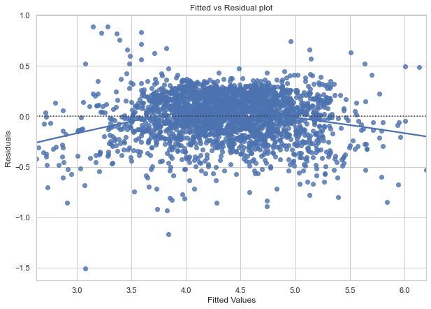

```
Wall time: 898 ms
```

```python
%%time

plt.figure(figsize=(10, 7))
sns.set_style("whitegrid")
sns.residplot(data=df_pred, x="Fitted Values", y="Residuals", lowess=True)
plt.xlabel("Fitted Values")
plt.ylabel("Residuals")
plt.title("Fitted vs Residual plot")
plt.show()
```

### TEST FOR NORMALITY

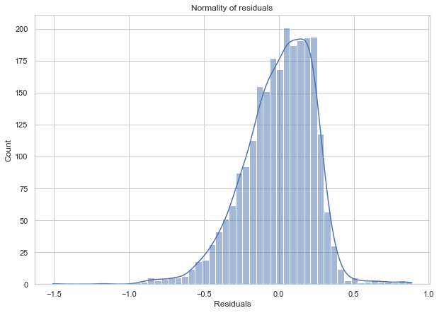

```python
plt.figure(figsize=(10, 7))
sns.histplot(df_pred["Residuals"], kde=True)
plt.title("Normality of residuals")
plt.show()
```

### Observations:

The data is slightly left skewed, but looks close to normal.

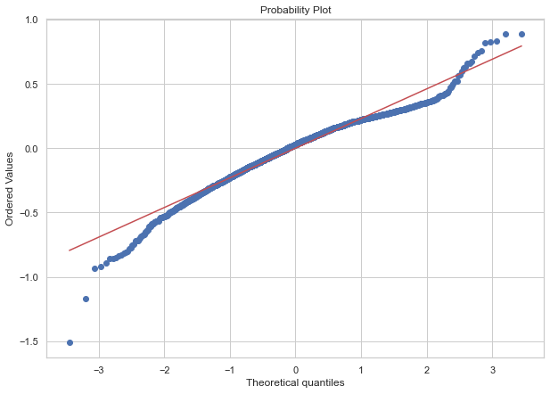

```python
import pylab
import scipy.stats as stats

plt.figure(figsize=(10, 7))
stats.probplot(df_pred["Residuals"], dist="norm", plot=pylab)
plt.show()
```

### Observations:

The data is not so good at the ends, but it is good in the middle. Close enough to work with.  
The data could possibly be modified to make the ends better, but that would require additional analysis of the data.

The Shapiro-Wilk test can also be used for checking the normality. The null and alternate hypotheses of the test are as follows:

- Null hypothesis - Data is normally distributed.
- Alternate hypothesis - Data is not normally distributed.

```python
statistic, p_value = stats.shapiro(df_pred["Residuals"])

print("statistic is:", statistic, "\np-value is: ", p_value)
```

```
statistic is: 0.9681875109672546
p-value is:  1.0292807180188988e-22
```

```python
# print the conclusion based on p-value
if p_value < 0.05:
    print(
        "As the p-value",
        p_value,
        "is less than the level of significance, we reject the null hypothesis.",
    )
else:
    print(
        "As the p-value",
        p_value,
        "is greater than the level of significance, we fail to reject the null hypothesis.",
    )
```

```
As the p-value 1.0292807180188988e-22 is less than the level of significance, we reject the null hypothesis.
```

### Observations:

A rejection of the null hypothesis is not surprizing as the data is not a pure normal distribution. However, it appears close enough to work with.

### TEST FOR HOMOSCEDASTICITY

- **Homoscedacity** - If the variance of the residuals are symmetrically distributed across the regression line , then the data is said to homoscedastic.
- **Heteroscedacity** - If the variance is unequal for the residuals across the regression line, then the data is said to be heteroscedastic. In this case the residuals can form an arrow shape or any other non symmetrical shape.

The null and alternate hypotheses of the goldfeldquandt test are as follows:

- Null hypothesis : Residuals are homoscedastic
- Alternate hypothesis : Residuals have hetroscedasticity

```python
import statsmodels.stats.api as sms
from statsmodels.compat import lzip
```

```python
name = ["F statistic", "p-value"]
test = sms.het_goldfeldquandt(df_pred["Residuals"], ind_train)
lzip(name, test)
```

```
[('F statistic', 1.0180047241439611), ('p-value', 0.3789233946528135)]
```

```python
p_value = 0.37892339465284025

if p_value < 0.05:
    print(
        "As the p-value",
        p_value,
        "is less than the level of significance, we reject the null hypothesis.",
    )
else:
    print(
        "As the p-value",
        p_value,
        "is greater than the level of significance, we fail to reject the null hypothesis.",
    )
```

```
As the p-value 0.37892339465284025 is greater than the level of significance, we fail to reject the null hypothesis.
```

### Observations:

Null hypothesis : Residuals are homoscedastic

## Final Model

```python
olsmod_final = sm.OLS(dep_train, ind_train)
olsres_final = olsmod_final.fit()
print(olsres_final.summary())
```

```
                              OLS Regression Results
=================================================================================
Dep. Variable:     normalized_used_price   R-squared:                       0.839
Model:                               OLS   Adj. R-squared:                  0.838
Method:                    Least Squares   F-statistic:                     963.8
Date:                   Sat, 21 May 2022   Prob (F-statistic):               0.00
Time:                           14:36:59   Log-Likelihood:                 79.355
No. Observations:                   2417   AIC:                            -130.7
Df Residuals:                       2403   BIC:                            -49.65
Df Model:                             13
Covariance Type:               nonrobust
========================================================================================
                           coef    std err          t      P>|t|      [0.025      0.975]
----------------------------------------------------------------------------------------
const                    1.5215      0.047     32.175      0.000       1.429       1.614
main_camera_mp           0.0212      0.001     15.147      0.000       0.018       0.024
selfie_camera_mp         0.0143      0.001     13.423      0.000       0.012       0.016
ram                      0.0223      0.005      4.432      0.000       0.012       0.032
weight                   0.0016   6.05e-05     27.224      0.000       0.002       0.002
normalized_new_price     0.4338      0.011     39.901      0.000       0.412       0.455
years_since_release     -0.0290      0.003     -8.520      0.000      -0.036      -0.022
brand_name_Karbonn       0.1223      0.055      2.233      0.026       0.015       0.230
brand_name_Lenovo        0.0533      0.022      2.462      0.014       0.011       0.096
brand_name_Nokia         0.0610      0.031      1.977      0.048       0.000       0.122
brand_name_Xiaomi        0.0891      0.026      3.470      0.001       0.039       0.140
os_Others               -0.1444      0.028     -5.089      0.000      -0.200      -0.089
4g_yes                   0.0460      0.015      3.059      0.002       0.017       0.076
5g_yes                  -0.0647      0.031     -2.111      0.035      -0.125      -0.005
==============================================================================
Omnibus:                      242.260   Durbin-Watson:                   1.914
Prob(Omnibus):                  0.000   Jarque-Bera (JB):              465.439
Skew:                          -0.657   Prob(JB):                    8.54e-102
Kurtosis:                       4.702   Cond. No.                     2.37e+03
==============================================================================

Notes:
[1] Standard Errors assume that the covariance matrix of the errors is correctly specified.
[2] The condition number is large, 2.37e+03. This might indicate that there are
strong multicollinearity or other numerical problems.
```

### Model Performance Check

```python
pred = olsres_final.predict(ind_train)
r2 = r2_score(dep_train, pred)

adjr2 = olsres_final.rsquared_adj

rmse = np.sqrt(mean_squared_error(dep_train, pred))

mae = mean_absolute_error(dep_train, pred)

mape = np.mean(np.abs(dep_train - pred) / dep_train) * 100

print(
    "For Training Data: \n" "RMSE =",
    rmse,
    "\nMAE =",
    mae,
    "\nR-squared =",
    r2,
    "\nAdj. R-squared =",
    adjr2,
    "\nMAPE =",
    mape[0],
)
```

```
For Training Data:
RMSE = 0.23415537784205645
MAE = 0.18320930792949622
R-squared = 0.839067963770661
Adj. R-squared = 0.8381973368580593
MAPE = nan
```

Original training R-squared and Adj. R-squared:

- R-squared is 84.48%
- Adj. R-squared is 84.17%

Final training R-squared and Adj. R-squared:

- R-squared is 83.90%
- Adj. R-squared is 83.81%

Both values dropped, but not by much. The training data is good.

```python
pred = olsres_final.predict(ind_test)
r2 = r2_score(dep_test, pred)

adjr2 = olsres_final.rsquared_adj

rmse = np.sqrt(mean_squared_error(dep_test, pred))

mae = mean_absolute_error(dep_test, pred)

mape = np.mean(np.abs(dep_test - pred) / dep_test) * 100

print(
    "For testing Data: \n" "RMSE =",
    rmse,
    "\nMAE =",
    mae,
    "\nR-squared =",
    r2,
    "\nAdj. R-squared =",
    adjr2,
    "\nMAPE =",
    mape[3],
)
```

```
For testing Data:
RMSE = 0.24144896740851718
MAE = 0.1876682459381784
R-squared = 0.8383671080705282
Adj. R-squared = 0.8381973368580593
MAPE = nan
```

Original testing R-squared and Adj. R-squared:

- R-squared is 84.24%
- Adj. R-squared is 84.17%

Current testing R-squared and Adj. R-squared:

- R-squared is 83.83%
- Adj. R-squared is 83.81%

Both values dropped, but not by much. The testing data is good.

Current training and testing values are very close. This is good.

### Print the linear regression equation

```python
# Check the model parameters

olsres_final.params
```

```
const                   1.521519
main_camera_mp          0.021216
selfie_camera_mp        0.014331
ram                     0.022344
weight                  0.001647
normalized_new_price    0.433808
years_since_release    -0.029015
brand_name_Karbonn      0.122328
brand_name_Lenovo       0.053329
brand_name_Nokia        0.061037
brand_name_Xiaomi       0.089140
os_Others              -0.144386
4g_yes                  0.046031
5g_yes                 -0.064665
dtype: float64
```

```python
# Write the equation of linear regression

Equation = "normalized used price ="
print(Equation, "\n", end=" ")
for i in range(len(ind_train.columns)):
    if i == 0:
        print(olsres_final.params[i], "+", "\n", end=" ")
    elif i != len(ind_train.columns) - 1:
        print(
            olsres_final.params[i],
            "* (",
            ind_train.columns[i],
            ")",
            "+",
            "\n",
            end="  ",
        )
    else:
        print(olsres_final.params[i], "* (", ind_train.columns[i], ")")

# I like having each component of the equation on a new line as it makes it easier to read
```

```
normalized used price =
 1.5215185676791267 +
 0.021216430248259907 * ( main_camera_mp ) +
  0.014330553556101747 * ( selfie_camera_mp ) +
  0.022344452823877235 * ( ram ) +
  0.001646828463120698 * ( weight ) +
  0.4338076727678882 * ( normalized_new_price ) +
  -0.029014723732971502 * ( years_since_release ) +
  0.12232819750688984 * ( brand_name_Karbonn ) +
  0.053329387346657375 * ( brand_name_Lenovo ) +
  0.06103677419606918 * ( brand_name_Nokia ) +
  0.08914034973475088 * ( brand_name_Xiaomi ) +
  -0.1443855959219721 * ( os_Others ) +
  0.04603134008975602 * ( 4g_yes ) +
  -0.06466540355782267 * ( 5g_yes )
```

## Actionable Insights

- These are the parameters that negativily affect the price:
  - years_since_release
  - os_Others
  - 5g_yes

These are the parameters that affect the price ordered from highest to lowest

1. normalized_new_price  
   0.433808
2. brand_name_Karbonn  
   0.122328
3. brand_name_Xiaomi  
   0.08914
4. brand_name_Nokia  
   0.061037
5. brand_name_Lenovo  
   0.053329
6. 4g_yes  
   0.046031
7. ram  
   0.022344
8. main_camera_mp  
   0.021216
9. selfie_camera_mp  
   0.014331
10. weight  
    0.001647

These brands have the lowest difference between the new and use price:

1. Infinix
2. Microsoft
3. Coolpad
4. Google
5. Realme
6. BlackBerry
7. Spice
8. Karbonn
9. OnePlus
10. Celkon
11. Lava
12. Panasonic
13. XOLO
14. Acer

## Recommendations

Unless they are very profitable, consider disposing of devices from 2013 and 2014 as they very old in terms of technology

## Future Recommendations

- Separate the cell phones from the tablets as they are inherently different and can be priced differently
- If not already done so, dispose of any 3g devices as they are no longer supported
  - There are 967 or approximately 28% of device which are more than likely 3g device or devices that cannot communicate over the cell phone network.
- Given there are 34 brands, consider doing a study to consider which ones are the most popular and profitable
  - Drop the brands that are the least popular and profitable
  - Focus on the brands and devices that are the most profitable and popular
- Track the device acquisition cost to determine profitability
- Keep device history to determine the number of times a device has been resold
- Focus on acquiring devices with high resolution main and selfie cameras as this has been a market driver for a number of years

## Final Thought

I am very glad to have been able to do all these calculations using a laptop and Python. I cannot image what it would be doing all these calculations by hand except to say it would have taken a VERY, VERY long time.

Charles Babbage would be very proud!